# Resource Selection Function Guide

Jessica Bonin

2023

# Resource Selection Function Guide

This GitHub page was created to allow the reader to follow along with the coding process of running an RSF.

## Cleaning

Cleaning the data is an important first step to any analysis.

### Initial Cleaning

The data we are using comes from GPS collars. This means there are rows within the raw data that are not usable. This can be due to the collar not collecting a location or collecting an inaccurate location. It is important to remove all rows with no data and with inaccurate data (determined here by the dilution measurement). In addition, the time the bears were in the den are removed. This will ensure that we are not extracting habitat use from a time when the bears are not actively changing resource use. We also wanted to convert the time of the GPS fixes from UTC to standard time. This will be more consistent with GIS layers. Seasons were decided on general habitat condition changes like food availability. Seasons were then added to the data in order to conduct seasonal analysis later on. Once the data are cleaned, it is important to have uniform structure to be able to use the data later on.

**Set Paths** Setting paths is important to make sure you are working with data in the correct file folder. It will vary based on where your personal data is stored

```r
path.root <- "C:/Users/jessi/University of Massachusetts/Jessica-BearProject - General/Final Data"
path.data <- paste(path.root, "/Raw Data", sep = "")
path.info <- paste(path.root, "/Bear Information", sep = "")
```

**Libraries** Installing and using the right packages is important to ensure your functions run properly.

```r
library(lubridate)
```

**List All Bear Files** This allows you to pull in all of the file names from one file folder. It is important to note that this is not the data itself, just the names of the files in the folder.

```r
setwd(path.data)
# Pulling in by the pattern lists every file in the folder with that syntax
# In this case we are using the file extension
file.list <- list.files(pattern = "\\.csv$", full.names = FALSE)
file.list
```

```
##   [1] "Allison2013.csv"        "Allison2014.csv"        "Amy2012.csv"
##   [4] "August2017.csv"         "August2018.csv"         "BabyP2021.csv"
##   [7] "BigPrescott2015.csv"    "BigPrescott2016.csv"    "BigPrescott2017.csv"
##  [10] "Bittersweet2017.csv"    "BlackHawk2020.csv"      "BlueMeadow2020.csv"
##  [13] "Bonnie2012.csv"         "Bonnie2013.csv"         "Bonnie2015.csv"
##  [16] "Brimfield2013.csv"      "Brimfield2014.csv"      "Brimfield2015.csv"
##  [19] "Broadbrook2014.csv"     "Broadbrook2015.csv"     "Broadbrook2016.csv"
##  [22] "Byrne2018.csv"          "Byrne2019.csv"          "Candace2012.csv"
##  [25] "Candace2013.csv"        "Candace2014.csv"        "Cascade2017.csv"
##  [28] "Cascade2018.csv"        "Coldbrook2013.csv"      "Coldbrook2015.csv"
##  [31] "Coldbrook2016.csv"      "Deck2020.csv"           "Deck2021.csv"
##  [34] "DRF349_2012.csv"        "DRF349_2013.csv"        "Emily2016.csv"
##  [37] "Emily2017.csv"          "Fairfield2018.csv"      "Fairfield2020.csv"
##  [40] "Fairfield2021.csv"      "Fitz2013.csv"           "Fitz2014.csv"
##  [43] "Fitz2015.csv"           "Fitz2016.csv"           "Ginger2017.csv"
```

[output cut: 33 more lines]

**Creating the Loop** Doing this in a loop allows R to run the code for each file one after the other.

```r
for (i in 1:length(file.list)){
# Calling In Bear Data
  # Set the path to pull data from the correct folder
setwd(path.data)
  # Defining the name of the bear from the base name of the each file in your list
name<- basename(file.list[i])
 # Pulling in the actual data using the list of file names
bear<-read.csv(paste0(file.list[i], sep=''))



# Calling In Organized Excel
 # Set the path to pull data from the correct folder
setwd(path.info)
 # This file holds information about the bears reproductive status, fix interval, and den exit and emergence
all.bear.info <- read.csv("Bear_Files_Organization.csv")

# Get Rid of Rows without Data
  # This deletes any row in the bear file that does not have GPS information
bear <- bear[!is.na(bear$GPS.Latitude),]


# Pull out bear row from organization file
bear.info <- all.bear.info[all.bear.info$bear == name, ]
bear.info

# Compare Columns for the Bear Info and Bear File
# Note that there are separate date and time columns in both
head(all.bear.info)
bear.info$den_exit <- paste(bear.info$den_exit_day, bear.info$den_exit_time_UTC)
bear.info$den_entry <- paste(bear.info$den_entry_day, bear.info$den_entry_time_UTC)


# Combine date and time columns and truncate for den
# Bear.info file
# Pull out values for exit and entry
den_exit <- bear.info$den_exit
den_entry <- bear.info$den_entry

# Removing Rows Before Den Emergence/Exit
bear <- bear[bear$GPS.Fix.Time >= den_exit, ]

# Removing Rows After Den Entry
bear <- bear[bear$GPS.Fix.Time <= den_entry, ]



# Deal with Date and Time
# The times for the data points need to be converted into UTC
datetime.est <-as.POSIXct(strptime(as.character(bear$GPS.Fix.Time), tz="UTC", "%Y.%m.%d %H:%M:%S"))
datetime.est <- format(datetime.est, tz = "America/New_York", usetz = TRUE)

bear$GPS.Fix.Time <- paste(datetime.est)



# Deal with Location Error
# Make sure the column names are the same for both types of collars
# For all collars, row 14 has the dilution measurement
names(bear)[14]<-paste("GPS.Positional.Dilution")

# This gets rid of all of the rows that have location data that may be errored
bear<-subset(bear,((bear$GPS.Fix.Attempt=="Resolved QFP (Uncertain)"|bear$GPS.Fix.Attempt=="Succeeded (2D)")&
                     bear$GPS.Positional.Dilution< 5)|
               ((bear$GPS.Fix.Attempt=="Succeeded (3D)"|bear$GPS.Fix.Attempt=='Resolved QFP')&
               bear$GPS.Positional.Dilution<20))


#Adding Seasons
# Season breakpoints in month-day format
Season.breaks<-as.Date(c("01-01","03-14","06-14","08-10","11-15","12-31"),format = "%m-%d")

# Convert season breakpoints to Julian day in numeric format
Season.breaks<-as.numeric(format(Season.breaks,format="%j"))

# Make a lookup table using a function in spatstat package
# Season.lut is a function that can be used in apply or a loop
# This step defines the season break dates an a categorical season
library(spatstat)
season.lut<-lut(as.factor(c("Winter","Spring","Summer","Fall","Winter")),breaks = Season.breaks)

# Make a new column with the fix dates without the exact time. This will be in the format Year-Month-Day
bear$short.fix.time <- bear$GPS.Fix.Time
bear$short.fix.time <- as.Date(bear$short.fix.time)


# Add a column to the data for season using the season.lut lookup table function
bear$season <- season.lut(as.numeric(format(bear$short.fix.time,format="%j")))

# Remove winter rows from data
bear <- bear[bear$season != "Winter", ]

# Remove rows with NAs for season
bear <- bear[!is.na(bear$season),]

# Add Bear Info to Bear File
bear$bear <- bear.info$bear
bear$name <- bear.info$name
bear$bear_number <- bear.info$bear_number
bear$year <- bear.info$year
bear$cub_status <- bear.info$cub_status

# Rename "GPS.Positional.Dilution" to "GPS.Dilution"
bear$GPS.Dilution <- bear$GPS.Positional.Dilution


# Make Columns Consistent with Other Collars
# GPS Fix Time, GPS Latitude, GPS Longitude

# Select Columns
keep.col <- c("bear", "name", "bear_number", "year", "cub_status", "GPS.Fix.Time", "GPS.Latitude", "GPS.Longitude", "GPS.Fix.Attempt", "GPS.Dilution", "season")
bear <- bear[keep.col]

# When it is finalized, save to "Bear Data Cleaned"
path.cleaned <- "C:/Users/jessi/University of Massachusetts/Jessica-BearProject - General/Final Data/Bear Data Cleaned"
setwd(path.cleaned)
fname=as.character(paste(file.list[i]))
#create output file with above name
write.csv(bear, file = fname, row.names = FALSE)
}
```

```
## spatstat.geom 3.2-5
```

```
## spatstat.random 3.1-5
```

```
## spatstat.explore 3.2-1
```

```
## spatstat.model 3.2-4
```

```
## spatstat.linnet 3.1-1
```

[output not shown]

### Removing Extreme Movements

Some of the bears took unusual movement paths while collared. The locations of these unusual movements can affect habitat analysis because it differs from normal patterns of behavior. We are not sure why this behavior occurs, but it could be due to a unique pressure put on an individual. For this reason, the data during those extreme movement patterns are removed from the data. The dates for the data being removed were determined manually by identifying the start and finish of the extreme movement path in ArcGIS.

**Libraries** Installing and using the right packages is important to ensure your functions run properly.

```r
library(dplyr)
```

**Set Paths** Setting paths is important to make sure you are working with data in the correct file folder. It will vary based on where your personal data is stored.

```r
path.root <- "C:/Users/jessi/University of Massachusetts/Jessica-BearProject - General/Final Data"
path.data <- paste(path.root, "/Bear Data Cleaned", sep = "")
path.ex.mov <- paste(path.root, "/Bear Information", sep = "")
path.save <- paste(path.root, "/Bear Data Cleaned", sep = "")
```

**Call in Extreme Movement Data** This file was manually created with the dates of the extreme movements identified in ArcGIS.

```r
# Set the path to pull data from the correct folder
setwd(path.ex.mov)
# This file has the date and time for when each of the bears start and end their extreme movement path
ex_movements <- read.csv("Extreme_Movements.csv")
```

**Call in Bears with Extreme Movements**

```r
# Set the path
setwd(path.data)

# Call in .csvs for the bears that were determined to make an unusual movement path
BigPrescott2017 <- read.csv("BigPrescott2017.csv")
Deck2021 <- read.csv("Deck2021.csv")
Emily2017 <- read.csv("Emily2017.csv")
Jersey2017 <- read.csv("Jersey2017.csv")
July2017 <- read.csv("July2017.csv")
Pelham465_2018 <- read.csv("Pelham465_2018.csv")
Sunderland2017 <- read.csv("Sunderland2017.csv")
Swift2017 <- read.csv("Swift2017.csv")
Templeton2017 <- read.csv("Templeton2017.csv")
Templeton2021 <- read.csv("Templeton2021.csv")
```

**List the Extreme Movements for Each Bear**

```r
# List the Extreme Movements for Each Bear
list(ex_movements)
```

```
## [[1]]
##               Bear                   Start                     End
## 1  BigPrescott2017 2017-09-26 14:45:39 EDT 2017-10-18 17:00:43 EDT
## 2         Deck2021 2021-10-07 13:15:21 EDT 2021-11-20 17:30:11 EST
## 3        Emily2017 2017-10-15 08:45:37 EDT 2017-11-06 15:15:37 EST
## 4       Jersey2017 2017-10-04 21:30:24 EDT 2017-10-18 21:30:19 EDT
## 5         July2017 2017-09-20 17:45:31 EDT 2017-11-13 11:30:20 EST
## 6   Pelham465_2018 2018-09-13 21:30:43 EDT 2018-11-23 04:00:37 EST
## 7   Sunderland2017 2017-10-03 23:45:25 EDT 2017-10-21 04:15:22 EDT
## 8        Swift2017 2017-09-06 20:45:39 EDT 2017-10-10 14:00:25 EDT
## 9    Templeton2017 2017-10-02 18:30:38 EDT 2017-12-23 19:45:30 EST
## 10   Templeton2021 2021-09-13 13:15:10 EDT 2021-11-07 12:15:47 EST
```

**Get Rid of the Rows that Fall Between the Start and End of BigPrescott2017 Extreme Movement Path**

```r
# Determine which rows are the start and end
which(BigPrescott2017$GPS.Fix.Time == '2017-09-26 14:45:39 EDT')
```

```
## [1] 3526
```

```r
which(BigPrescott2017$GPS.Fix.Time == '2017-10-18 17:00:43 EDT')
```

```
## [1] 3950
```

```r
# Remove the rows that fall in the extreme movements
BigPrescott2017 <- BigPrescott2017[-(3526:3950),]
```

**Get Rid of the Rows that Fall Between the Start and End of Deck2021 Extreme Movement Path**

```r
# Determine which rows are the start and end
which(Deck2021$GPS.Fix.Time == '2021-10-07 13:15:21 EDT')
```

```
## [1] 5586
```

```r
which(Deck2021$GPS.Fix.Time == '2021-11-20 17:30:11 EST')
```

```
## integer(0)
```

```r
# Remove the rows that fall in the extreme movements
Deck2021 <- Deck2021[-(5586: 7010),]
```

**Get Rid of the Rows that Fall Between the Start and End of Emily2017 Extreme Movement Path**

```r
# Determine which rows are the start and end
which(Emily2017$GPS.Fix.Time == '2017-10-15 08:45:37 EDT')
```

```
## [1] 3907
```

```r
which(Emily2017$GPS.Fix.Time == '2017-11-06 15:15:37 EST')
```

```
## [1] 4358
```

```r
# Remove the rows that fall in the extreme movements
Emily2017 <- Emily2017[-(3907:4358),]
```

**Get Rid of the Rows that Fall Between the Start and End of Jersey2017 Extreme Movement Path**

```r
# Determine which rows are the start and end
which(Jersey2017$GPS.Fix.Time == '2017-10-04 21:30:24 EDT')
```

```
## [1] 2123
```

```r
which(Jersey2017$GPS.Fix.Time == '2017-10-18 21:30:19 EDT')
```

```
## [1] 2415
```

```r
# Remove the rows that fall in the extreme movements
Jersey2017 <- Jersey2017[-(2123:2415),]
```

**Get Rid of the Rows that Fall Between the Start and End of July2017 Extreme Movement Path**

```r
# Determine which rows are the start and end
which(July2017$GPS.Fix.Time == '2017-09-20 17:45:31 EDT')
```

```
## [1] 3587
```

```r
which(July2017$GPS.Fix.Time == '2017-11-13 11:30:20 EST')
```

```
## [1] 4762
```

```r
# Remove the rows that fall in the extreme movements
July2017 <- July2017[-(3587:4762),]
```

**Get Rid of the Rows that Fall Between the Start and End of Pelham465_2018 Extreme Movement Path**

```r
# Determine which rows are the start and end
which(Pelham465_2018$GPS.Fix.Time == '2018-09-13 21:30:43 EDT')
```

```
## [1] 3311
```

```r
which(Pelham465_2018$GPS.Fix.Time == '2018-11-23 04:00:37 EST')
```

```
## integer(0)
```

```r
# Remove the rows that fall in the extreme movements
Pelham465_2018 <- Pelham465_2018[-(3311:4815),]
```

**Get Rid of the Rows that Fall Between the Start and End of Sunderland2017 Extreme Movement Path**

```r
# Determine which rows are the start and end
which(Sunderland2017$GPS.Fix.Time == '2017-10-03 23:45:25 EDT')
```

```
## [1] 4154
```

```r
which(Sunderland2017$GPS.Fix.Time == '2017-10-21 04:15:22 EDT')
```

```
## [1] 4551
```

```r
# Remove the rows that fall in the extreme movements
Sunderland2017 <- Sunderland2017[-(4154:4551),]
```

**Get Rid of the Rows that Fall Between the Start and End of Swift2017 Extreme Movement Path**

```r
# Determine which rows are the start and end
which(Swift2017$GPS.Fix.Time == '2017-09-06 20:45:39 EDT')
```

```
## [1] 2761
```

```r
which(Swift2017$GPS.Fix.Time == '2017-10-10 14:00:25 EDT')
```

```
## [1] 3255
```

```r
# Remove the rows that fall in the extreme movements
Swift2017 <- Swift2017[-(2761:3255),]
```

**Get Rid of the Rows that Fall Between the Start and End of Templeton2017 Extreme Movement Path**

```r
# Determine which rows are the start and end
which(Templeton2017$GPS.Fix.Time == '2017-10-02 18:30:38 EDT')
```

```
## [1] 1695
```

```r
which(Templeton2017$GPS.Fix.Time == '2017-12-23 19:45:30 EST')
```

```
## integer(0)
```

```r
# Remove the rows that fall in the extreme movements
Templeton2017 <- Templeton2017[-(1695:3353),]
```

**Get Rid of the Rows that Fall Between the Start and End of Templeton2021 Extreme Movement Path**

```r
# Determine which rows are the start and end
which(Templeton2021$GPS.Fix.Time == '2021-09-13 13:15:10 EDT')
```

```
## [1] 5433
```

```r
which(Templeton2021$GPS.Fix.Time == '2021-11-07 12:15:47 EST')
```

```
## [1] 7190
```

```r
# Remove the rows that fall in the extreme movements
Templeton2021 <- Templeton2021[-(5433:7190),]
```

**Save to replace**

```r
# Set the path to pull data from the correct folder
setwd(path.save)
# Save the files with the same name to replace the existing files that include the extreme movement rows
write.csv(BigPrescott2017, file = "BigPrescott2017.csv", row.names = FALSE)
write.csv(Deck2021, file = "Deck2021.csv", row.names = FALSE)
write.csv(Emily2017, file = "Emily2017.csv", row.names = FALSE)
write.csv(Jersey2017, file = "Jersey2017.csv", row.names = FALSE)
write.csv(July2017, file = "July2017.csv", row.names = FALSE)
write.csv(Pelham465_2018, file = "Pelham465_2018.csv", row.names = FALSE)
write.csv(Sunderland2017, file = "Sunderland2017.csv", row.names = FALSE)
write.csv(Swift2017, file = "Swift2017.csv", row.names = FALSE)
write.csv(Templeton2017, file ="Templeton2017.csv", row.names = FALSE)
write.csv(Templeton2021, file ="Templeton2021.csv", row.names = FALSE)
```

## Creating Shapefiles

After the data are cleaned, shapefiles are created to have the data as spatially referenced. This takes the data for each GIS location and assigns it to a spatially referenced point. For this project, we want all data to be referenced to UTM Zone 18 North. This data was collected using World Geodetic System 1984. Note: CRS stands for Coordinate Reference System.

**Set Paths** Set the path pick the file folder to pull in your data. It will be different based on where your data is stored.

```r
path.root <- "C:/Users/jessi/University of Massachusetts/Jessica-BearProject - General/Final Data"
path.data <- paste(path.root, "/Bear Data Cleaned", sep = "")
path.save <- paste(path.root, "/Cleaned Bear Data Shapefiles", sep = "")
```

**Libraries** Make sure to install and pull in the libraries you need in order for your code functions to work.

```r
require(sf)
require(dplyr)
require(psych)
library(raster)
library(sp)
library(dismo)
library(stringr)
require(stars)
library(rgdal)
library(readxl)
```

**Define Projection Strings** The projection string tells R what projection your data is in. If the projection is wrong or not defined, the data will not be graphically located correctly.

```r
# Assign the projection string
# WGS84 - World Geodetic System 1984
# The data was collected referencing this projection
prj.wgs84 <- "+proj=longlat +ellps=WGS84 +datum=WGS84 +no_defs"
LatLong <- crs(prj.wgs84)

# WGS 84 / UTM zone 18N
# We want the final data to be referencing this projection
prj.utmWGSz18 <- "+proj=utm +zone=18 +ellps=WGS84 +datum=WGS84 +units=m +no_defs"
UTM18 <- crs(prj.utmWGSz18)
```

**List All Bear Files** This allows you to pull in all of the file names from one file folder. It is important to note that this is not the data itself, just the names of the files in the folder.

```r
setwd(path.data)
# Pulling in by the pattern lists every file in the folder with that syntax
# In this case we are using the file extension
file.list <- list.files(pattern = "\\.csv$", full.names = FALSE)
file.list
```

```
##   [1] "Allison2013.csv"        "Allison2014.csv"        "Amy2012.csv"
##   [4] "August2017.csv"         "August2018.csv"         "BabyP2021.csv"
##   [7] "BigPrescott2015.csv"    "BigPrescott2016.csv"    "BigPrescott2017.csv"
##  [10] "Bittersweet2017.csv"    "BlackHawk2020.csv"      "BlueMeadow2020.csv"
##  [13] "Bonnie2012.csv"         "Bonnie2013.csv"         "Bonnie2015.csv"
##  [16] "Brimfield2013.csv"      "Brimfield2014.csv"      "Brimfield2015.csv"
##  [19] "Broadbrook2014.csv"     "Broadbrook2015.csv"     "Broadbrook2016.csv"
##  [22] "Byrne2018.csv"          "Byrne2019.csv"          "Candace2012.csv"
##  [25] "Candace2013.csv"        "Candace2014.csv"        "Cascade2017.csv"
##  [28] "Cascade2018.csv"        "Coldbrook2013.csv"      "Coldbrook2015.csv"
##  [31] "Coldbrook2016.csv"      "Deck2020.csv"           "Deck2021.csv"
##  [34] "DRF349_2012.csv"        "DRF349_2013.csv"        "Emily2016.csv"
##  [37] "Emily2017.csv"          "Fairfield2018.csv"      "Fairfield2020.csv"
##  [40] "Fairfield2021.csv"      "Fitz2013.csv"           "Fitz2014.csv"
##  [43] "Fitz2015.csv"           "Fitz2016.csv"           "Ginger2017.csv"
```

[output cut: 33 more lines]

**Creating the Shapefiles From .csv Data** Doing this in a loop allows R to run the code for each file one after the other.

```r
for (i in 1:length(file.list)){
# Calling In Bear Data
# Set the path to pull data from the correct folder
setwd(path.data)
# Defining the name of the bear from the base name of the each file in your list
name<- basename(file.list[i])
# Pulling in the actual data using the list of file names
bear<-read.csv(paste0(file.list[i], sep=''))


# Convert the .csv files to an spatial frame object and define its projection
bear <- st_as_sf(bear, coords = c("GPS.Longitude", "GPS.Latitude"), crs = LatLong)
st_crs(bear)


# Transform into UTM Zone 18 N
# The EPSG code form UTM Zone 18 North is 32618
bear_UTM <- st_transform(bear, crs = UTM18)
st_crs(bear_UTM) <- 32618


# Export As a Shapefile
setwd(path.save)
fname=as.character(paste(file.list[i]))
fname = paste(fname, sep = "_")
fname <- gsub('.csv', '', fname)
st_write(bear_UTM, fname, driver = "ESRI Shapefile", append=FALSE)
}
```

```
## Deleting layer `Allison2013' using driver `ESRI Shapefile'
## Writing layer `Allison2013' to data source `Allison2013' using driver `ESRI Shapefile'
## Writing 5639 features with 9 fields and geometry type Point.
```

```
## Deleting layer `Allison2014' using driver `ESRI Shapefile'
## Writing layer `Allison2014' to data source `Allison2014' using driver `ESRI Shapefile'
## Writing 999 features with 9 fields and geometry type Point.
```

```
## Deleting layer `Amy2012' using driver `ESRI Shapefile'
## Writing layer `Amy2012' to data source `Amy2012' using driver `ESRI Shapefile'
## Writing 3487 features with 9 fields and geometry type Point.
```

```
## Deleting layer `August2017' using driver `ESRI Shapefile'
## Writing layer `August2017' to data source `August2017' using driver `ESRI Shapefile'
## Writing 4222 features with 9 fields and geometry type Point.
```

```
## Deleting layer `August2018' using driver `ESRI Shapefile'
## Writing layer `August2018' to data source `August2018' using driver `ESRI Shapefile'
## Writing 2909 features with 9 fields and geometry type Point.
```

```
## Deleting layer `BabyP2021' using driver `ESRI Shapefile'
## Writing layer `BabyP2021' to data source `BabyP2021' using driver `ESRI Shapefile'
## Writing 7780 features with 9 fields and geometry type Point.
```

```
## Deleting layer `BigPrescott2015' using driver `ESRI Shapefile'
## Writing layer `BigPrescott2015' to data source
##   `BigPrescott2015' using driver `ESRI Shapefile'
## Writing 2742 features with 9 fields and geometry type Point.
```

```
## Deleting layer `BigPrescott2016' using driver `ESRI Shapefile'
## Writing layer `BigPrescott2016' to data source
##   `BigPrescott2016' using driver `ESRI Shapefile'
## Writing 4337 features with 9 fields and geometry type Point.
```

```
## Deleting layer `BigPrescott2017' using driver `ESRI Shapefile'
## Writing layer `BigPrescott2017' to data source
##   `BigPrescott2017' using driver `ESRI Shapefile'
## Writing 4133 features with 9 fields and geometry type Point.
```

```
## Deleting layer `Bittersweet2017' using driver `ESRI Shapefile'
## Writing layer `Bittersweet2017' to data source
##   `Bittersweet2017' using driver `ESRI Shapefile'
## Writing 4011 features with 9 fields and geometry type Point.
```

```
## Deleting layer `BlackHawk2020' using driver `ESRI Shapefile'
## Writing layer `BlackHawk2020' to data source
##   `BlackHawk2020' using driver `ESRI Shapefile'
## Writing 5616 features with 9 fields and geometry type Point.
```

```
## Deleting layer `BlueMeadow2020' using driver `ESRI Shapefile'
## Writing layer `BlueMeadow2020' to data source
##   `BlueMeadow2020' using driver `ESRI Shapefile'
## Writing 4333 features with 9 fields and geometry type Point.
```

```
## Deleting layer `Bonnie2012' using driver `ESRI Shapefile'
## Writing layer `Bonnie2012' to data source `Bonnie2012' using driver `ESRI Shapefile'
## Writing 4056 features with 9 fields and geometry type Point.
```

```
## Deleting layer `Bonnie2013' using driver `ESRI Shapefile'
## Writing layer `Bonnie2013' to data source `Bonnie2013' using driver `ESRI Shapefile'
## Writing 4730 features with 9 fields and geometry type Point.
```

```
## Deleting layer `Bonnie2015' using driver `ESRI Shapefile'
## Writing layer `Bonnie2015' to data source `Bonnie2015' using driver `ESRI Shapefile'
## Writing 839 features with 9 fields and geometry type Point.
```

```
## Deleting layer `Brimfield2013' using driver `ESRI Shapefile'
## Writing layer `Brimfield2013' to data source
##   `Brimfield2013' using driver `ESRI Shapefile'
## Writing 3173 features with 9 fields and geometry type Point.
```

```
## Deleting layer `Brimfield2014' using driver `ESRI Shapefile'
## Writing layer `Brimfield2014' to data source
##   `Brimfield2014' using driver `ESRI Shapefile'
## Writing 4135 features with 9 fields and geometry type Point.
```

```
## Deleting layer `Brimfield2015' using driver `ESRI Shapefile'
## Writing layer `Brimfield2015' to data source
##   `Brimfield2015' using driver `ESRI Shapefile'
## Writing 4055 features with 9 fields and geometry type Point.
```

```
## Deleting layer `Broadbrook2014' using driver `ESRI Shapefile'
## Writing layer `Broadbrook2014' to data source
##   `Broadbrook2014' using driver `ESRI Shapefile'
## Writing 2108 features with 9 fields and geometry type Point.
```

```
## Deleting layer `Broadbrook2015' using driver `ESRI Shapefile'
## Writing layer `Broadbrook2015' to data source
##   `Broadbrook2015' using driver `ESRI Shapefile'
## Writing 3303 features with 9 fields and geometry type Point.
```

```
## Deleting layer `Broadbrook2016' using driver `ESRI Shapefile'
## Writing layer `Broadbrook2016' to data source
##   `Broadbrook2016' using driver `ESRI Shapefile'
## Writing 3854 features with 9 fields and geometry type Point.
```

```
## Deleting layer `Byrne2018' using driver `ESRI Shapefile'
## Writing layer `Byrne2018' to data source `Byrne2018' using driver `ESRI Shapefile'
## Writing 2745 features with 9 fields and geometry type Point.
```

```
## Deleting layer `Byrne2019' using driver `ESRI Shapefile'
## Writing layer `Byrne2019' to data source `Byrne2019' using driver `ESRI Shapefile'
## Writing 5698 features with 9 fields and geometry type Point.
```

```
## Deleting layer `Candace2012' using driver `ESRI Shapefile'
## Writing layer `Candace2012' to data source `Candace2012' using driver `ESRI Shapefile'
## Writing 3667 features with 9 fields and geometry type Point.
```

```
## Deleting layer `Candace2013' using driver `ESRI Shapefile'
## Writing layer `Candace2013' to data source `Candace2013' using driver `ESRI Shapefile'
## Writing 2887 features with 9 fields and geometry type Point.
```

```
## Deleting layer `Candace2014' using driver `ESRI Shapefile'
## Writing layer `Candace2014' to data source `Candace2014' using driver `ESRI Shapefile'
## Writing 3527 features with 9 fields and geometry type Point.
```

```
## Deleting layer `Cascade2017' using driver `ESRI Shapefile'
## Writing layer `Cascade2017' to data source `Cascade2017' using driver `ESRI Shapefile'
## Writing 2329 features with 9 fields and geometry type Point.
```

```
## Deleting layer `Cascade2018' using driver `ESRI Shapefile'
## Writing layer `Cascade2018' to data source `Cascade2018' using driver `ESRI Shapefile'
## Writing 3919 features with 9 fields and geometry type Point.
```

```
## Deleting layer `Coldbrook2013' using driver `ESRI Shapefile'
## Writing layer `Coldbrook2013' to data source
##   `Coldbrook2013' using driver `ESRI Shapefile'
## Writing 3740 features with 9 fields and geometry type Point.
```

```
## Deleting layer `Coldbrook2015' using driver `ESRI Shapefile'
## Writing layer `Coldbrook2015' to data source
##   `Coldbrook2015' using driver `ESRI Shapefile'
## Writing 4014 features with 9 fields and geometry type Point.
```

```
## Deleting layer `Coldbrook2016' using driver `ESRI Shapefile'
## Writing layer `Coldbrook2016' to data source
##   `Coldbrook2016' using driver `ESRI Shapefile'
## Writing 4379 features with 9 fields and geometry type Point.
```

```
## Deleting layer `Deck2020' using driver `ESRI Shapefile'
## Writing layer `Deck2020' to data source `Deck2020' using driver `ESRI Shapefile'
## Writing 6620 features with 9 fields and geometry type Point.
```

```
## Deleting layer `Deck2021' using driver `ESRI Shapefile'
## Writing layer `Deck2021' to data source `Deck2021' using driver `ESRI Shapefile'
## Writing 5585 features with 9 fields and geometry type Point.
```

```
## Deleting layer `DRF349_2012' using driver `ESRI Shapefile'
## Writing layer `DRF349_2012' to data source `DRF349_2012' using driver `ESRI Shapefile'
## Writing 2115 features with 9 fields and geometry type Point.
```

```
## Deleting layer `DRF349_2013' using driver `ESRI Shapefile'
## Writing layer `DRF349_2013' to data source `DRF349_2013' using driver `ESRI Shapefile'
## Writing 2078 features with 9 fields and geometry type Point.
```

```
## Deleting layer `Emily2016' using driver `ESRI Shapefile'
## Writing layer `Emily2016' to data source `Emily2016' using driver `ESRI Shapefile'
## Writing 8034 features with 9 fields and geometry type Point.
```

```
## Deleting layer `Emily2017' using driver `ESRI Shapefile'
## Writing layer `Emily2017' to data source `Emily2017' using driver `ESRI Shapefile'
## Writing 4100 features with 9 fields and geometry type Point.
```

```
## Deleting layer `Fairfield2018' using driver `ESRI Shapefile'
## Writing layer `Fairfield2018' to data source
##   `Fairfield2018' using driver `ESRI Shapefile'
## Writing 2593 features with 9 fields and geometry type Point.
```

```
## Deleting layer `Fairfield2020' using driver `ESRI Shapefile'
## Writing layer `Fairfield2020' to data source
##   `Fairfield2020' using driver `ESRI Shapefile'
## Writing 7195 features with 9 fields and geometry type Point.
```

```
## Deleting layer `Fairfield2021' using driver `ESRI Shapefile'
## Writing layer `Fairfield2021' to data source
##   `Fairfield2021' using driver `ESRI Shapefile'
## Writing 7568 features with 9 fields and geometry type Point.
```

```
## Deleting layer `Fitz2013' using driver `ESRI Shapefile'
## Writing layer `Fitz2013' to data source `Fitz2013' using driver `ESRI Shapefile'
## Writing 2790 features with 9 fields and geometry type Point.
```

```
## Deleting layer `Fitz2014' using driver `ESRI Shapefile'
## Writing layer `Fitz2014' to data source `Fitz2014' using driver `ESRI Shapefile'
## Writing 3746 features with 9 fields and geometry type Point.
```

```
## Deleting layer `Fitz2015' using driver `ESRI Shapefile'
## Writing layer `Fitz2015' to data source `Fitz2015' using driver `ESRI Shapefile'
## Writing 4044 features with 9 fields and geometry type Point.
```

```
## Deleting layer `Fitz2016' using driver `ESRI Shapefile'
## Writing layer `Fitz2016' to data source `Fitz2016' using driver `ESRI Shapefile'
## Writing 11271 features with 9 fields and geometry type Point.
```

```
## Deleting layer `Ginger2017' using driver `ESRI Shapefile'
## Writing layer `Ginger2017' to data source `Ginger2017' using driver `ESRI Shapefile'
## Writing 2410 features with 9 fields and geometry type Point.
```

```
## Deleting layer `Ginger2018' using driver `ESRI Shapefile'
## Writing layer `Ginger2018' to data source `Ginger2018' using driver `ESRI Shapefile'
## Writing 4115 features with 9 fields and geometry type Point.
```

```
## Deleting layer `Ginger2020' using driver `ESRI Shapefile'
## Writing layer `Ginger2020' to data source `Ginger2020' using driver `ESRI Shapefile'
## Writing 7221 features with 9 fields and geometry type Point.
```

```
## Deleting layer `Ginger2021' using driver `ESRI Shapefile'
## Writing layer `Ginger2021' to data source `Ginger2021' using driver `ESRI Shapefile'
## Writing 2652 features with 9 fields and geometry type Point.
```

```
## Deleting layer `Gleason2020' using driver `ESRI Shapefile'
## Writing layer `Gleason2020' to data source `Gleason2020' using driver `ESRI Shapefile'
## Writing 7426 features with 9 fields and geometry type Point.
```

```
## Deleting layer `Gleason2021' using driver `ESRI Shapefile'
## Writing layer `Gleason2021' to data source `Gleason2021' using driver `ESRI Shapefile'
## Writing 7276 features with 9 fields and geometry type Point.
```

```
## Deleting layer `Grace2020' using driver `ESRI Shapefile'
## Writing layer `Grace2020' to data source `Grace2020' using driver `ESRI Shapefile'
## Writing 7763 features with 9 fields and geometry type Point.
```

```
## Deleting layer `Grace2021' using driver `ESRI Shapefile'
## Writing layer `Grace2021' to data source `Grace2021' using driver `ESRI Shapefile'
## Writing 7173 features with 9 fields and geometry type Point.
```

```
## Deleting layer `Grainger2015' using driver `ESRI Shapefile'
## Writing layer `Grainger2015' to data source
##   `Grainger2015' using driver `ESRI Shapefile'
## Writing 2972 features with 9 fields and geometry type Point.
```

```
## Deleting layer `Granby2_2018' using driver `ESRI Shapefile'
## Writing layer `Granby2_2018' to data source
##   `Granby2_2018' using driver `ESRI Shapefile'
## Writing 4433 features with 9 fields and geometry type Point.
```

```
## Deleting layer `Granby2_2019' using driver `ESRI Shapefile'
## Writing layer `Granby2_2019' to data source
##   `Granby2_2019' using driver `ESRI Shapefile'
## Writing 5526 features with 9 fields and geometry type Point.
```

```
## Deleting layer `Granby2_2020' using driver `ESRI Shapefile'
## Writing layer `Granby2_2020' to data source
##   `Granby2_2020' using driver `ESRI Shapefile'
## Writing 7213 features with 9 fields and geometry type Point.
```

```
## Deleting layer `Granby2_2021' using driver `ESRI Shapefile'
## Writing layer `Granby2_2021' to data source
##   `Granby2_2021' using driver `ESRI Shapefile'
## Writing 7355 features with 9 fields and geometry type Point.
```

```
## Deleting layer `Granby2013' using driver `ESRI Shapefile'
## Writing layer `Granby2013' to data source `Granby2013' using driver `ESRI Shapefile'
## Writing 4409 features with 9 fields and geometry type Point.
```

```
## Deleting layer `Granby2014' using driver `ESRI Shapefile'
## Writing layer `Granby2014' to data source `Granby2014' using driver `ESRI Shapefile'
## Writing 5018 features with 9 fields and geometry type Point.
```

```
## Deleting layer `Granby2015' using driver `ESRI Shapefile'
## Writing layer `Granby2015' to data source `Granby2015' using driver `ESRI Shapefile'
## Writing 3293 features with 9 fields and geometry type Point.
```

```
## Deleting layer `Granby2016' using driver `ESRI Shapefile'
## Writing layer `Granby2016' to data source `Granby2016' using driver `ESRI Shapefile'
## Writing 3141 features with 9 fields and geometry type Point.
```

```
## Deleting layer `Granby2020' using driver `ESRI Shapefile'
## Writing layer `Granby2020' to data source `Granby2020' using driver `ESRI Shapefile'
## Writing 7647 features with 9 fields and geometry type Point.
```

```
## Deleting layer `Hatch2015' using driver `ESRI Shapefile'
## Writing layer `Hatch2015' to data source `Hatch2015' using driver `ESRI Shapefile'
## Writing 1502 features with 9 fields and geometry type Point.
```

```
## Deleting layer `Henrietta2020' using driver `ESRI Shapefile'
## Writing layer `Henrietta2020' to data source
##   `Henrietta2020' using driver `ESRI Shapefile'
## Writing 1624 features with 9 fields and geometry type Point.
```

```
## Deleting layer `HillOtis2018' using driver `ESRI Shapefile'
## Writing layer `HillOtis2018' to data source
##   `HillOtis2018' using driver `ESRI Shapefile'
## Writing 2869 features with 9 fields and geometry type Point.
```

```
## Deleting layer `Holiday2016' using driver `ESRI Shapefile'
## Writing layer `Holiday2016' to data source `Holiday2016' using driver `ESRI Shapefile'
## Writing 3809 features with 9 fields and geometry type Point.
```

```
## Deleting layer `Holiday2017' using driver `ESRI Shapefile'
## Writing layer `Holiday2017' to data source `Holiday2017' using driver `ESRI Shapefile'
## Writing 4263 features with 9 fields and geometry type Point.
```

```
## Deleting layer `Holiday2018' using driver `ESRI Shapefile'
## Writing layer `Holiday2018' to data source `Holiday2018' using driver `ESRI Shapefile'
## Writing 3218 features with 9 fields and geometry type Point.
```

```
## Deleting layer `Holyoke2020' using driver `ESRI Shapefile'
## Writing layer `Holyoke2020' to data source `Holyoke2020' using driver `ESRI Shapefile'
## Writing 4364 features with 9 fields and geometry type Point.
```

```
## Deleting layer `Holyoke2021' using driver `ESRI Shapefile'
## Writing layer `Holyoke2021' to data source `Holyoke2021' using driver `ESRI Shapefile'
## Writing 6444 features with 9 fields and geometry type Point.
```

```
## Deleting layer `Hoosac2019' using driver `ESRI Shapefile'
## Writing layer `Hoosac2019' to data source `Hoosac2019' using driver `ESRI Shapefile'
## Writing 2893 features with 9 fields and geometry type Point.
```

```
## Deleting layer `Jersey2017' using driver `ESRI Shapefile'
## Writing layer `Jersey2017' to data source `Jersey2017' using driver `ESRI Shapefile'
## Writing 2719 features with 9 fields and geometry type Point.
```

```
## Deleting layer `Jersey2018' using driver `ESRI Shapefile'
## Writing layer `Jersey2018' to data source `Jersey2018' using driver `ESRI Shapefile'
## Writing 4532 features with 9 fields and geometry type Point.
```

```
## Deleting layer `JetBlue2018' using driver `ESRI Shapefile'
## Writing layer `JetBlue2018' to data source `JetBlue2018' using driver `ESRI Shapefile'
## Writing 2568 features with 9 fields and geometry type Point.
```

```
## Deleting layer `Juliet2020' using driver `ESRI Shapefile'
## Writing layer `Juliet2020' to data source `Juliet2020' using driver `ESRI Shapefile'
## Writing 7552 features with 9 fields and geometry type Point.
```

```
## Deleting layer `Juliet2021' using driver `ESRI Shapefile'
## Writing layer `Juliet2021' to data source `Juliet2021' using driver `ESRI Shapefile'
## Writing 7011 features with 9 fields and geometry type Point.
```

```
## Deleting layer `July2015' using driver `ESRI Shapefile'
## Writing layer `July2015' to data source `July2015' using driver `ESRI Shapefile'
## Writing 2097 features with 9 fields and geometry type Point.
```

```
## Deleting layer `July2016' using driver `ESRI Shapefile'
## Writing layer `July2016' to data source `July2016' using driver `ESRI Shapefile'
## Writing 3660 features with 9 fields and geometry type Point.
```

```
## Deleting layer `July2017' using driver `ESRI Shapefile'
## Writing layer `July2017' to data source `July2017' using driver `ESRI Shapefile'
## Writing 3625 features with 9 fields and geometry type Point.
```

```
## Deleting layer `July2018' using driver `ESRI Shapefile'
## Writing layer `July2018' to data source `July2018' using driver `ESRI Shapefile'
## Writing 3754 features with 9 fields and geometry type Point.
```

```
## Deleting layer `June2015' using driver `ESRI Shapefile'
## Writing layer `June2015' to data source `June2015' using driver `ESRI Shapefile'
## Writing 2459 features with 9 fields and geometry type Point.
```

```
## Deleting layer `June2016' using driver `ESRI Shapefile'
## Writing layer `June2016' to data source `June2016' using driver `ESRI Shapefile'
## Writing 9411 features with 9 fields and geometry type Point.
```

```
## Deleting layer `Katherine2012' using driver `ESRI Shapefile'
## Writing layer `Katherine2012' to data source
##   `Katherine2012' using driver `ESRI Shapefile'
## Writing 3571 features with 9 fields and geometry type Point.
```

```
## Deleting layer `Katherine2013' using driver `ESRI Shapefile'
## Writing layer `Katherine2013' to data source
##   `Katherine2013' using driver `ESRI Shapefile'
## Writing 5794 features with 9 fields and geometry type Point.
```

```
## Deleting layer `Katherine2016' using driver `ESRI Shapefile'
## Writing layer `Katherine2016' to data source
##   `Katherine2016' using driver `ESRI Shapefile'
## Writing 4736 features with 9 fields and geometry type Point.
```

```
## Deleting layer `Leverett2020' using driver `ESRI Shapefile'
## Writing layer `Leverett2020' to data source
##   `Leverett2020' using driver `ESRI Shapefile'
## Writing 1939 features with 9 fields and geometry type Point.
```

```
## Deleting layer `LittlePrescott2015' using driver `ESRI Shapefile'
## Writing layer `LittlePrescott2015' to data source
##   `LittlePrescott2015' using driver `ESRI Shapefile'
## Writing 2124 features with 9 fields and geometry type Point.
```

```
## Deleting layer `LittlePrescott2016' using driver `ESRI Shapefile'
## Writing layer `LittlePrescott2016' to data source
##   `LittlePrescott2016' using driver `ESRI Shapefile'
## Writing 4216 features with 9 fields and geometry type Point.
```

```
## Deleting layer `LittlePrescott2017' using driver `ESRI Shapefile'
## Writing layer `LittlePrescott2017' to data source
##   `LittlePrescott2017' using driver `ESRI Shapefile'
## Writing 4610 features with 9 fields and geometry type Point.
```

```
## Deleting layer `May2012' using driver `ESRI Shapefile'
## Writing layer `May2012' to data source `May2012' using driver `ESRI Shapefile'
## Writing 2174 features with 9 fields and geometry type Point.
```

```
## Deleting layer `May2013' using driver `ESRI Shapefile'
## Writing layer `May2013' to data source `May2013' using driver `ESRI Shapefile'
## Writing 1857 features with 9 fields and geometry type Point.
```

```
## Deleting layer `Northampton2018' using driver `ESRI Shapefile'
## Writing layer `Northampton2018' to data source
##   `Northampton2018' using driver `ESRI Shapefile'
## Writing 2719 features with 9 fields and geometry type Point.
```

```
## Deleting layer `Northampton2020' using driver `ESRI Shapefile'
## Writing layer `Northampton2020' to data source
##   `Northampton2020' using driver `ESRI Shapefile'
## Writing 2365 features with 9 fields and geometry type Point.
```

```
## Deleting layer `Northampton2021' using driver `ESRI Shapefile'
## Writing layer `Northampton2021' to data source
##   `Northampton2021' using driver `ESRI Shapefile'
## Writing 6957 features with 9 fields and geometry type Point.
```

```
## Deleting layer `OD2020' using driver `ESRI Shapefile'
## Writing layer `OD2020' to data source `OD2020' using driver `ESRI Shapefile'
## Writing 3254 features with 9 fields and geometry type Point.
```

```
## Deleting layer `Pelham373_2013' using driver `ESRI Shapefile'
## Writing layer `Pelham373_2013' to data source
##   `Pelham373_2013' using driver `ESRI Shapefile'
## Writing 2632 features with 9 fields and geometry type Point.
```

```
## Deleting layer `Pelham373_2014' using driver `ESRI Shapefile'
## Writing layer `Pelham373_2014' to data source
##   `Pelham373_2014' using driver `ESRI Shapefile'
## Writing 3353 features with 9 fields and geometry type Point.
```

```
## Deleting layer `Pelham373_2015' using driver `ESRI Shapefile'
## Writing layer `Pelham373_2015' to data source
##   `Pelham373_2015' using driver `ESRI Shapefile'
## Writing 2639 features with 9 fields and geometry type Point.
```

```
## Deleting layer `Pelham465_2017' using driver `ESRI Shapefile'
## Writing layer `Pelham465_2017' to data source
##   `Pelham465_2017' using driver `ESRI Shapefile'
## Writing 3332 features with 9 fields and geometry type Point.
```

```
## Deleting layer `Pelham465_2018' using driver `ESRI Shapefile'
## Writing layer `Pelham465_2018' to data source
##   `Pelham465_2018' using driver `ESRI Shapefile'
## Writing 3310 features with 9 fields and geometry type Point.
```

```
## Deleting layer `Pistachio2020' using driver `ESRI Shapefile'
## Writing layer `Pistachio2020' to data source
##   `Pistachio2020' using driver `ESRI Shapefile'
## Writing 2349 features with 9 fields and geometry type Point.
```

```
## Deleting layer `Pistachio2021' using driver `ESRI Shapefile'
## Writing layer `Pistachio2021' to data source
##   `Pistachio2021' using driver `ESRI Shapefile'
## Writing 7189 features with 9 fields and geometry type Point.
```

```
## Deleting layer `PolandBrook2016' using driver `ESRI Shapefile'
## Writing layer `PolandBrook2016' to data source
##   `PolandBrook2016' using driver `ESRI Shapefile'
## Writing 4143 features with 9 fields and geometry type Point.
```

```
## Deleting layer `PolandBrook2017' using driver `ESRI Shapefile'
## Writing layer `PolandBrook2017' to data source
##   `PolandBrook2017' using driver `ESRI Shapefile'
## Writing 4285 features with 9 fields and geometry type Point.
```

```
## Deleting layer `Quabbin2013' using driver `ESRI Shapefile'
## Writing layer `Quabbin2013' to data source `Quabbin2013' using driver `ESRI Shapefile'
## Writing 3962 features with 9 fields and geometry type Point.
```

```
## Deleting layer `Quabbin2014' using driver `ESRI Shapefile'
## Writing layer `Quabbin2014' to data source `Quabbin2014' using driver `ESRI Shapefile'
## Writing 3265 features with 9 fields and geometry type Point.
```

```
## Deleting layer `Quabbin2016' using driver `ESRI Shapefile'
## Writing layer `Quabbin2016' to data source `Quabbin2016' using driver `ESRI Shapefile'
## Writing 7013 features with 9 fields and geometry type Point.
```

```
## Deleting layer `Rachel2014' using driver `ESRI Shapefile'
## Writing layer `Rachel2014' to data source `Rachel2014' using driver `ESRI Shapefile'
## Writing 3268 features with 9 fields and geometry type Point.
```

```
## Deleting layer `Rachel2015' using driver `ESRI Shapefile'
## Writing layer `Rachel2015' to data source `Rachel2015' using driver `ESRI Shapefile'
## Writing 3189 features with 9 fields and geometry type Point.
```

```
## Deleting layer `Ruby2012' using driver `ESRI Shapefile'
## Writing layer `Ruby2012' to data source `Ruby2012' using driver `ESRI Shapefile'
## Writing 3783 features with 9 fields and geometry type Point.
```

```
## Deleting layer `Ruby2013' using driver `ESRI Shapefile'
## Writing layer `Ruby2013' to data source `Ruby2013' using driver `ESRI Shapefile'
## Writing 2326 features with 9 fields and geometry type Point.
```

```
## Deleting layer `Shelley2012' using driver `ESRI Shapefile'
## Writing layer `Shelley2012' to data source `Shelley2012' using driver `ESRI Shapefile'
## Writing 392 features with 9 fields and geometry type Point.
```

```
## Deleting layer `Shelley2013' using driver `ESRI Shapefile'
## Writing layer `Shelley2013' to data source `Shelley2013' using driver `ESRI Shapefile'
## Writing 3455 features with 9 fields and geometry type Point.
```

```
## Deleting layer `Shelley2014' using driver `ESRI Shapefile'
## Writing layer `Shelley2014' to data source `Shelley2014' using driver `ESRI Shapefile'
## Writing 4185 features with 9 fields and geometry type Point.
```

```
## Deleting layer `Shelley2015' using driver `ESRI Shapefile'
## Writing layer `Shelley2015' to data source `Shelley2015' using driver `ESRI Shapefile'
## Writing 3528 features with 9 fields and geometry type Point.
```

```
## Deleting layer `Shelley2016' using driver `ESRI Shapefile'
## Writing layer `Shelley2016' to data source `Shelley2016' using driver `ESRI Shapefile'
## Writing 12187 features with 9 fields and geometry type Point.
```

```
## Deleting layer `Shirley2020' using driver `ESRI Shapefile'
## Writing layer `Shirley2020' to data source `Shirley2020' using driver `ESRI Shapefile'
## Writing 5570 features with 9 fields and geometry type Point.
```

```
## Deleting layer `Shirley2021' using driver `ESRI Shapefile'
## Writing layer `Shirley2021' to data source `Shirley2021' using driver `ESRI Shapefile'
## Writing 1624 features with 9 fields and geometry type Point.
```

```
## Deleting layer `Solar2019' using driver `ESRI Shapefile'
## Writing layer `Solar2019' to data source `Solar2019' using driver `ESRI Shapefile'
## Writing 5317 features with 9 fields and geometry type Point.
```

```
## Deleting layer `Solar2020' using driver `ESRI Shapefile'
## Writing layer `Solar2020' to data source `Solar2020' using driver `ESRI Shapefile'
## Writing 3333 features with 9 fields and geometry type Point.
```

```
## Deleting layer `SouthHadley2020' using driver `ESRI Shapefile'
## Writing layer `SouthHadley2020' to data source
##   `SouthHadley2020' using driver `ESRI Shapefile'
## Writing 7140 features with 9 fields and geometry type Point.
```

```
## Deleting layer `SouthHadley2021' using driver `ESRI Shapefile'
## Writing layer `SouthHadley2021' to data source
##   `SouthHadley2021' using driver `ESRI Shapefile'
## Writing 7476 features with 9 fields and geometry type Point.
```

```
## Deleting layer `Sterling2021' using driver `ESRI Shapefile'
## Writing layer `Sterling2021' to data source
##   `Sterling2021' using driver `ESRI Shapefile'
## Writing 5896 features with 9 fields and geometry type Point.
```

```
## Deleting layer `Sunderland2_2019' using driver `ESRI Shapefile'
## Writing layer `Sunderland2_2019' to data source
##   `Sunderland2_2019' using driver `ESRI Shapefile'
## Writing 2856 features with 9 fields and geometry type Point.
```

```
## Deleting layer `Sunderland2017' using driver `ESRI Shapefile'
## Writing layer `Sunderland2017' to data source
##   `Sunderland2017' using driver `ESRI Shapefile'
## Writing 4770 features with 9 fields and geometry type Point.
```

```
## Deleting layer `Sunderland2018' using driver `ESRI Shapefile'
## Writing layer `Sunderland2018' to data source
##   `Sunderland2018' using driver `ESRI Shapefile'
## Writing 4727 features with 9 fields and geometry type Point.
```

```
## Deleting layer `Sunderland2019' using driver `ESRI Shapefile'
## Writing layer `Sunderland2019' to data source
##   `Sunderland2019' using driver `ESRI Shapefile'
## Writing 4779 features with 9 fields and geometry type Point.
```

```
## Deleting layer `Sunderland2020' using driver `ESRI Shapefile'
## Writing layer `Sunderland2020' to data source
##   `Sunderland2020' using driver `ESRI Shapefile'
## Writing 4755 features with 9 fields and geometry type Point.
```

```
## Deleting layer `Sunderland3_2019' using driver `ESRI Shapefile'
## Writing layer `Sunderland3_2019' to data source
##   `Sunderland3_2019' using driver `ESRI Shapefile'
## Writing 5772 features with 9 fields and geometry type Point.
```

```
## Deleting layer `Sunderland3_2020' using driver `ESRI Shapefile'
## Writing layer `Sunderland3_2020' to data source
##   `Sunderland3_2020' using driver `ESRI Shapefile'
## Writing 2791 features with 9 fields and geometry type Point.
```

```
## Deleting layer `Swift2017' using driver `ESRI Shapefile'
## Writing layer `Swift2017' to data source `Swift2017' using driver `ESRI Shapefile'
## Writing 3242 features with 9 fields and geometry type Point.
```

```
## Deleting layer `Swift2018' using driver `ESRI Shapefile'
## Writing layer `Swift2018' to data source `Swift2018' using driver `ESRI Shapefile'
## Writing 3905 features with 9 fields and geometry type Point.
```

```
## Deleting layer `Tamarack2018' using driver `ESRI Shapefile'
## Writing layer `Tamarack2018' to data source
##   `Tamarack2018' using driver `ESRI Shapefile'
## Writing 2964 features with 9 fields and geometry type Point.
```

```
## Deleting layer `Tamarack2020' using driver `ESRI Shapefile'
## Writing layer `Tamarack2020' to data source
##   `Tamarack2020' using driver `ESRI Shapefile'
## Writing 7339 features with 9 fields and geometry type Point.
```

```
## Deleting layer `Templeton2017' using driver `ESRI Shapefile'
## Writing layer `Templeton2017' to data source
##   `Templeton2017' using driver `ESRI Shapefile'
## Writing 1694 features with 9 fields and geometry type Point.
```

```
## Deleting layer `Templeton2018' using driver `ESRI Shapefile'
## Writing layer `Templeton2018' to data source
##   `Templeton2018' using driver `ESRI Shapefile'
## Writing 3486 features with 9 fields and geometry type Point.
```

```
## Deleting layer `Templeton2020' using driver `ESRI Shapefile'
## Writing layer `Templeton2020' to data source
##   `Templeton2020' using driver `ESRI Shapefile'
## Writing 7116 features with 9 fields and geometry type Point.
```

```
## Deleting layer `Templeton2021' using driver `ESRI Shapefile'
## Writing layer `Templeton2021' to data source
##   `Templeton2021' using driver `ESRI Shapefile'
## Writing 5684 features with 9 fields and geometry type Point.
```

```
## Deleting layer `Towns2013' using driver `ESRI Shapefile'
## Writing layer `Towns2013' to data source `Towns2013' using driver `ESRI Shapefile'
## Writing 4233 features with 9 fields and geometry type Point.
```

```
## Deleting layer `Whately2012' using driver `ESRI Shapefile'
## Writing layer `Whately2012' to data source `Whately2012' using driver `ESRI Shapefile'
## Writing 951 features with 9 fields and geometry type Point.
```

```
## Deleting layer `Whately2013' using driver `ESRI Shapefile'
## Writing layer `Whately2013' to data source `Whately2013' using driver `ESRI Shapefile'
## Writing 1743 features with 9 fields and geometry type Point.
```

```
## Deleting layer `Whately2014' using driver `ESRI Shapefile'
## Writing layer `Whately2014' to data source `Whately2014' using driver `ESRI Shapefile'
## Writing 270 features with 9 fields and geometry type Point.
```

## MCPs

The home range of each bear will be determined using a Minimum Convex Polygon. We will generate a 99% MCP (meaning generating a border around 99% of the data points). This ensures that if any extreme fixes were not removed during data cleaning, the home range calculation will not include the area where that point lies. We will also include a 200-meter buffer around the MCP. This is to include the area around the use locations that is still available for the bear to go. We chose 200 meters because it is the average step length between the 45-minute time intervals.

**Libraries** Installing and using the right packages is important to ensure your functions run properly.

```r
library(adehabitatHR)
library(sp)
library(rgdal)
library(sf)
```

**Set Paths** Setting paths is important to make sure you are working with data in the correct file folder. It will vary based on where your personal data is stored.

```r
path.root <- "C:/Users/jessi/University of Massachusetts/Jessica-BearProject - General/Final Data"
path.data <- paste(path.root, "/Bear Data Cleaned", sep = "")
```

**List All Bear Files** This allows you to pull in all of the file names from one file folder. It is important to note that this is not the data itself, just the names of the files in the folder.

```r
setwd(path.data)
file.list <- list.files(pattern = "\\.csv$", full.names = FALSE)
file.list
```

```
##   [1] "Allison2013.csv"        "Allison2014.csv"        "Amy2012.csv"
##   [4] "August2017.csv"         "August2018.csv"         "BabyP2021.csv"
##   [7] "BigPrescott2015.csv"    "BigPrescott2016.csv"    "BigPrescott2017.csv"
##  [10] "Bittersweet2017.csv"    "BlackHawk2020.csv"      "BlueMeadow2020.csv"
##  [13] "Bonnie2012.csv"         "Bonnie2013.csv"         "Bonnie2015.csv"
##  [16] "Brimfield2013.csv"      "Brimfield2014.csv"      "Brimfield2015.csv"
##  [19] "Broadbrook2014.csv"     "Broadbrook2015.csv"     "Broadbrook2016.csv"
##  [22] "Byrne2018.csv"          "Byrne2019.csv"          "Candace2012.csv"
##  [25] "Candace2013.csv"        "Candace2014.csv"        "Cascade2017.csv"
##  [28] "Cascade2018.csv"        "Coldbrook2013.csv"      "Coldbrook2015.csv"
##  [31] "Coldbrook2016.csv"      "Deck2020.csv"           "Deck2021.csv"
##  [34] "DRF349_2012.csv"        "DRF349_2013.csv"        "Emily2016.csv"
##  [37] "Emily2017.csv"          "Fairfield2018.csv"      "Fairfield2020.csv"
##  [40] "Fairfield2021.csv"      "Fitz2013.csv"           "Fitz2014.csv"
##  [43] "Fitz2015.csv"           "Fitz2016.csv"           "Ginger2017.csv"
```

[output cut: 33 more lines]

**Creating the Loop to convert data into UTM Zone 18 North and create the MCP with a buffer** Doing this in a loop allows R to run the code for each file one after the other.

```r
for (i in 1:length(file.list)){
# Calling In Bear Data
  # Set the path to pull data from the correct folder
setwd(path.data)
# Defining the name of the bear from the base name of the each file in your list
name<- basename(file.list[i])
 # Pulling in the actual data using the list of file names
bear<-read.csv(paste0(file.list[i], sep=''))

# Make a function to convert WGS84 to UTM
# Data was collected in reference to WGS84
LongLatToUTM<-function(x,y,zone){
 xy <- data.frame(ID = 1:length(x), X = x, Y = y)
 coordinates(xy) <- c("X", "Y")
 proj4string(xy) <- CRS("+proj=longlat +datum=WGS84")
 res <- spTransform(xy, CRS(paste("+proj=utm +zone=18 +ellps=WGS84 +datum=WGS84 +units=m +no_defs",sep='')))
 return(as.data.frame(res))
}
# Define the longitude and latitude as x and y
x <- bear$GPS.Longitude
y <- bear$GPS.Latitude
# Use the function to convert to UTM
bear.sp = LongLatToUTM(x,y,18)
# Change the column names
colnames(bear.sp) <- c("name", "X", "Y")
bear.sp$name = name
# Tell R that the X (longitude) and Y (latitude) are the coordinates for the data
coordinates(bear.sp) <- c("X", "Y")
# Define the coordinate reference system to UTM
proj4string(bear.sp) <- CRS("+proj=utm +zone=18 +ellps=WGS84 +datum=WGS84 +units=m +no_defs")



# Generate the MCP
bear.mcp <- mcp(bear.sp, percent = 99)
bear.mcp
# Define the projection string as UTM Zone 18 N
proj4string(bear.mcp) <- CRS("+proj=utm +zone=18 +ellps=WGS84 +datum=WGS84 +units=m +no_defs")

# Add a 200 meter buffer
library(rgeos)
buffer <- gBuffer(bear.mcp, width = 200, byid = T)
proj4string(buffer) <- CRS("+proj=utm +zone=18 +ellps=WGS84 +datum=WGS84 +units=m +no_defs")

# Export As a Shapefile
setwd(path.root)
fname=as.character(paste(file.list[i]))
fname <- gsub('.csv', '', fname)
writeOGR(buffer, "MCPs", fname, driver = "ESRI Shapefile", check_exists=TRUE, overwrite_layer = TRUE)
}
```

[output not shown]

## Generating Random Points

Random points are generated to assess available resources.

### Density of Points

To determine how many random points would accurately represent availability we calculated a density of points using 9 bear MCPs. For these 9 bears, we determined the minimum number of points to accurately represent land use within the home range. We calculated the density of points for each bear by dividing the minimum number of points by the area of the home range. The average density of points was determined to be 105.8 points per square kilometer.

**Libraries** Installing and using the right packages is important to ensure your functions run properly.

```r
require(sf)
require(dplyr)
require(psych)
library(raster)
library(sp)
library(dismo)
library(stringr)
require(stars)
```

**Set Paths** Setting paths is important to make sure you are working with data in the correct file folder. It will vary based on where your personal data is stored.

```r
path.root <- "C:/Users/jessi/University of Massachusetts/Jessica-BearProject - General/Final Data"
path.data <- paste(path.root, "/Bear Data Cleaned", sep = "")
path.mcp.data <- paste(path.root, "/MCPs", sep = "")
```

**Pull in MCPs of bears used for exploratory analysis**

```r
setwd(path.mcp.data)
Amy2012_MCP <- read_sf("Amy2012.shp")
Bittersweet2017_MCP <- read_sf("Bittersweet2017.shp")
BlackHawk2020_MCP <- read_sf("BlackHawk2020.shp")
Bonnie2013_MCP <- read_sf("Bonnie2013.shp")
Granby2_2018_MCP <- read_sf("Granby2_2018.shp")
LittlePrescott2015_MCP <- read_sf("LittlePrescott2015.shp")
Shirley2020_MCP <- read_sf("Shirley2020.shp")
Solar2019_MCP <- read_sf("Solar2019.shp")
Templeton2018_MCP <- read_sf("Templeton2018.shp")
```

**Convert area from meters squared to sq km** Divide the area value by 1e+6

```r
# Define the crs as UTM Zone 18 North then convert MCP area to sq Km
st_crs(Amy2012_MCP) <- 32618
Amy2012_MCP$area_km_sq <- (st_area(Amy2012_MCP)/1000000)
# Define the crs as UTM Zone 18 North then convert MCP area to sq Km
st_crs(Bittersweet2017_MCP)<- 32618
Bittersweet2017_MCP$area_km_sq <- (st_area(Bittersweet2017_MCP)/1000000)
# Define the crs as UTM Zone 18 North then convert MCP area to sq Km
st_crs(BlackHawk2020_MCP)<- 32618
BlackHawk2020_MCP$area_km_sq <- (st_area(BlackHawk2020_MCP)/1000000)
# Define the crs as UTM Zone 18 North then convert MCP area to sq Km
st_crs(Bonnie2013_MCP)<- 32618
Bonnie2013_MCP$area_km_sq <- (st_area(Bonnie2013_MCP)/1000000)
# Define the crs as UTM Zone 18 North then convert MCP area to sq Km
st_crs(Granby2_2018_MCP)<- 32618
Granby2_2018_MCP$area_km_sq <- (st_area(Granby2_2018_MCP)/1000000)
# Define the crs as UTM Zone 18 North then convert MCP area to sq Km
st_crs(LittlePrescott2015_MCP)<- 32618
LittlePrescott2015_MCP$area_km_sq <- (st_area(LittlePrescott2015_MCP)/1000000)
# Define the crs as UTM Zone 18 North then convert MCP area to sq Km
st_crs(Shirley2020_MCP)<- 32618
Shirley2020_MCP$area_km_sq <- (st_area(Shirley2020_MCP)/1000000)
# Define the crs as UTM Zone 18 North then convert MCP area to sq Km
st_crs(Solar2019_MCP)<- 32618
Solar2019_MCP$area_km_sq <-(st_area(Solar2019_MCP)/1000000)
# Define the crs as UTM Zone 18 North then convert MCP area to sq Km
st_crs(Templeton2018_MCP)<- 32618
Templeton2018_MCP$area_km_sq <- (st_area(Templeton2018_MCP)/1000000)
```

**Create a matrix to put minimum number of points, MCP area, and density of points calculated**

```r
min_points <- matrix(0, nrow = 9, ncol = 3)
# Make the row names the bear
rownames(min_points) <- c("Amy2012","Bittersweet2017","BlackHawk2020","Bonnie2013","Granby2_2018","LittlePrescott2015","Shirley2020","Solar2019","Templeton2018")
# Define the column names
colnames(min_points) <- c("Min_no_Pts", "area", "Den_of_Pts")
```

**Add the predetermined minimum number of points to the first row of the matrix**

```r
# Amy2012
min_points[1,1] <- 6000
# Bittersweet2017
min_points[2,1] <- 6000
# BlackHawk2020
min_points[3,1] <- 6000
# Bonnie2013
min_points[4,1] <- 4500
# Granby2_2018
min_points[5,1] <- 3500
# LittlePrescott2015
min_points[6,1] <- 8000
# Shirley2020
min_points[7,1] <- 4000
# Solar2019
min_points[8,1] <- 6000
# Templeton2018
min_points[9,1] <- 8000
```

**Add the area of each home range to the second column of the matrix**

```r
min_points[1,2] <- Amy2012_MCP$area_km_sq
min_points[2,2] <- Bittersweet2017_MCP$area_km_sq
min_points[3,2] <- BlackHawk2020_MCP$area_km_sq
min_points[4,2] <- Bonnie2013_MCP$area_km_sq
min_points[5,2] <- Granby2_2018_MCP$area_km_sq
min_points[6,2] <- LittlePrescott2015_MCP$area_km_sq
min_points[7,2] <- Shirley2020_MCP$area_km_sq
min_points[8,2] <- Solar2019_MCP$area_km_sq
min_points[9,2] <- Templeton2018_MCP$area_km_sq
```

**Calculate Density of Points for Each Bear by dividing the minimum number of points by the area of the home range** This will go into the third column of the matrix

```r
min_points <- as.data.frame(min_points)
# Density of points = min number of points/area
min_points$Den_of_Pts <- ((min_points$Min_no_Pts)/(min_points$area))
min_points
```

```
##                    Min_no_Pts      area Den_of_Pts
## Amy2012                  6000  46.96819  127.74604
## Bittersweet2017          6000  21.58004  278.03476
## BlackHawk2020            6000  81.09308   73.98905
## Bonnie2013               4500 313.33814   14.36148
## Granby2_2018             3500  99.89523   35.03671
## LittlePrescott2015       8000  96.06702   83.27520
## Shirley2020              4000 190.69253   20.97618
## Solar2019                6000  20.22130  296.71680
## Templeton2018            8000 354.58251   22.56174
```

**Calculate the average Density of Points for the 9 bears**

```r
# Calculate the mean density of points
Density_of_Points <- mean(min_points$Den_of_Pts)
print(Density_of_Points)
```

```
## [1] 105.8553
```

### Generating

Random points need to be generated for each MCP to determine what is available for the bear to use. RSFs compare use points (GPS locations) to available points (random points in each MCP) to determine selection. We used a density of points for each MCP to determine how many random points would accurately represent availability. The density of points was determined to be 105.8 Points per square kilometer.

**Libraries** Installing and using the right packages is important to ensure your functions run properly.

```r
require(sf)
require(dplyr)
require(psych)
library(raster)
library(sp)
library(dismo)
library(stringr)
require(stars)
library(rgdal)
library(readxl)
```

**Set Paths** Setting paths is important to make sure you are working with data in the correct file folder. It will vary based on where your personal data is stored.

```r
path.root <- "C:/Users/jessi/University of Massachusetts/Jessica-BearProject - General/Final Data"
path.mcp.data <- paste(path.root, "/MCPs", sep = "")
path.info <- paste(path.root, "/Bear Information", sep = "")
path.save <- paste(path.root, "/Availability Points Shapefiles", sep = "")
```

**List All Bear Files** This allows you to pull in all of the file names from one file folder. It is important to note that this is not the data itself, just the names of the files in the folder.

```r
setwd(path.mcp.data)
# Pulling in by the pattern lists every file in the folder with that syntax
# In this case we are using the file extension
file.list <- list.files(pattern = "\\.shp$", full.names = FALSE)
file.list
```

```
##   [1] "Allison2013.shp"        "Allison2014.shp"        "Amy2012.shp"
##   [4] "August2017.shp"         "August2018.shp"         "BabyP2021.shp"
##   [7] "BigPrescott2015.shp"    "BigPrescott2016.shp"    "BigPrescott2017.shp"
##  [10] "Bittersweet2017.shp"    "BlackHawk2020.shp"      "BlueMeadow2020.shp"
##  [13] "Bonnie2012.shp"         "Bonnie2013.shp"         "Bonnie2015.shp"
##  [16] "Brimfield2013.shp"      "Brimfield2014.shp"      "Brimfield2015.shp"
##  [19] "Broadbrook2014.shp"     "Broadbrook2015.shp"     "Broadbrook2016.shp"
##  [22] "Byrne2018.shp"          "Byrne2019.shp"          "Candace2012.shp"
##  [25] "Candace2013.shp"        "Candace2014.shp"        "Cascade2017.shp"
##  [28] "Cascade2018.shp"        "Coldbrook2013.shp"      "Coldbrook2015.shp"
##  [31] "Coldbrook2016.shp"      "Deck2020.shp"           "Deck2021.shp"
##  [34] "DRF349_2012.shp"        "DRF349_2013.shp"        "Emily2016.shp"
##  [37] "Emily2017.shp"          "Fairfield2018.shp"      "Fairfield2020.shp"
##  [40] "Fairfield2021.shp"      "Fitz2013.shp"           "Fitz2014.shp"
##  [43] "Fitz2015.shp"           "Fitz2016.shp"           "Ginger2017.shp"
```

[output cut: 33 more lines]

**Calling in bear info** This file contains basic information including bear, name, bear_number, year, and cub_status

```r
setwd(path.info)
bear.info <- read_excel("Bear_Files_Summary.xlsx")
```

**Create a matrix to put the calculated number of random points needed for each bear**

```r
# Create matix
no_of_rand_points <- matrix(0, length(file.list), ncol = 3)
# Define the column names
colnames(no_of_rand_points) <- c("Bear","Area", "No_of_Rand_Pts")
```

**Calculate Number of Random Points for Each MCP** Density of Points = 105.8 Points Per Sq Km

```r
for (i in 1:length(file.list)){
# Calling In MCP Data
setwd(path.mcp.data)
# Defining the name of the bear from the base name of the each file in your list
name <- basename(file.list[i])
# Using gsub will delete the file extension from the name
name <- gsub('.shp', '', name)
mcp <- read_sf(paste0(file.list[i], sep=''))


# Define projection of the MCPs
st_crs(mcp) <- 32618
# Convert area from meters squared to sq km
# Divide the area value by 1e+6
mcp$area_km_sq <- (st_area(mcp)/1000000)

# Add the information to the maxtrix created earlier
# Column 1: The name if the bear with year
no_of_rand_points[i,1] <- name
# Column 2: The area in square kilometers
no_of_rand_points[i,2] <- mcp$area_km_sq
# Column 3: The number of points to generate. Calculated by multiplying the area by the density of points
no_of_rand_points[i,3] <- (mcp$area_km_sq*105.8)

# List as numeric
rand_pts <- as.numeric(no_of_rand_points[i,3])

# Generate Random Points

# Rasterize the MCP
mcp_R <- st_rasterize(mcp %>% dplyr::select(geometry))
mcp_R <- as(mcp_R, "Raster")

# Create Random Points
bear_RP <- randomPoints(mcp_R, rand_pts)
bear_RP <- as.data.frame(bear_RP)

# Define x and y into environments
x <- bear_RP$x
y <- bear_RP$y
# Convert the random points tp spatial frame object
bear_RP <- st_as_sf(x = bear_RP, coords = c("x", "y"), crs = "+proj=utm +zone=18 +ellps=WGS84 +datum=WGS84 +units=m +no_defs")

# Add all columns to match use data
# Subset the bear info by pulling out the row for the bear iteration
bear_info <- bear.info[bear.info$bear == name,]

# Add that information to the generated random points
bear_RP <-cbind(bear_RP,bear_info)

# Export As a Shapefile
setwd(path.save)
fname = as.character(paste(file.list[i]))
RP <- "RP"
fname = paste(RP, fname, sep = "_")
fname <- gsub('.csv', '', fname)
st_write(bear_RP, fname, driver = "ESRI Shapefile", append=FALSE)
}
```

```
## Deleting layer `RP_Allison2013' using driver `ESRI Shapefile'
## Writing layer `RP_Allison2013' to data source
##   `RP_Allison2013.shp' using driver `ESRI Shapefile'
## Writing 4332 features with 5 fields and geometry type Point.
```

```
## Deleting layer `RP_Allison2014' using driver `ESRI Shapefile'
## Writing layer `RP_Allison2014' to data source
##   `RP_Allison2014.shp' using driver `ESRI Shapefile'
## Writing 2735 features with 5 fields and geometry type Point.
```

```
## Deleting layer `RP_Amy2012' using driver `ESRI Shapefile'
## Writing layer `RP_Amy2012' to data source
##   `RP_Amy2012.shp' using driver `ESRI Shapefile'
## Writing 4969 features with 5 fields and geometry type Point.
```

```
## Deleting layer `RP_August2017' using driver `ESRI Shapefile'
## Writing layer `RP_August2017' to data source
##   `RP_August2017.shp' using driver `ESRI Shapefile'
## Writing 12338 features with 5 fields and geometry type Point.
```

```
## Deleting layer `RP_August2018' using driver `ESRI Shapefile'
## Writing layer `RP_August2018' to data source
##   `RP_August2018.shp' using driver `ESRI Shapefile'
## Writing 9942 features with 5 fields and geometry type Point.
```

```
## Deleting layer `RP_BabyP2021' using driver `ESRI Shapefile'
## Writing layer `RP_BabyP2021' to data source
##   `RP_BabyP2021.shp' using driver `ESRI Shapefile'
## Writing 6386 features with 5 fields and geometry type Point.
```

```
## Deleting layer `RP_BigPrescott2015' using driver `ESRI Shapefile'
## Writing layer `RP_BigPrescott2015' to data source
##   `RP_BigPrescott2015.shp' using driver `ESRI Shapefile'
## Writing 5017 features with 5 fields and geometry type Point.
```

```
## Deleting layer `RP_BigPrescott2016' using driver `ESRI Shapefile'
## Writing layer `RP_BigPrescott2016' to data source
##   `RP_BigPrescott2016.shp' using driver `ESRI Shapefile'
## Writing 5926 features with 5 fields and geometry type Point.
```

```
## Deleting layer `RP_BigPrescott2017' using driver `ESRI Shapefile'
## Writing layer `RP_BigPrescott2017' to data source
##   `RP_BigPrescott2017.shp' using driver `ESRI Shapefile'
## Writing 17572 features with 5 fields and geometry type Point.
```

```
## Deleting layer `RP_Bittersweet2017' using driver `ESRI Shapefile'
## Writing layer `RP_Bittersweet2017' to data source
##   `RP_Bittersweet2017.shp' using driver `ESRI Shapefile'
## Writing 2283 features with 5 fields and geometry type Point.
```

```
## Deleting layer `RP_BlackHawk2020' using driver `ESRI Shapefile'
## Writing layer `RP_BlackHawk2020' to data source
##   `RP_BlackHawk2020.shp' using driver `ESRI Shapefile'
## Writing 8579 features with 5 fields and geometry type Point.
```

```
## Deleting layer `RP_BlueMeadow2020' using driver `ESRI Shapefile'
## Writing layer `RP_BlueMeadow2020' to data source
##   `RP_BlueMeadow2020.shp' using driver `ESRI Shapefile'
## Writing 5782 features with 5 fields and geometry type Point.
```

```
## Deleting layer `RP_Bonnie2012' using driver `ESRI Shapefile'
## Writing layer `RP_Bonnie2012' to data source
##   `RP_Bonnie2012.shp' using driver `ESRI Shapefile'
## Writing 20668 features with 5 fields and geometry type Point.
```

```
## Deleting layer `RP_Bonnie2013' using driver `ESRI Shapefile'
## Writing layer `RP_Bonnie2013' to data source
##   `RP_Bonnie2013.shp' using driver `ESRI Shapefile'
## Writing 33151 features with 5 fields and geometry type Point.
```

```
## Deleting layer `RP_Bonnie2015' using driver `ESRI Shapefile'
## Writing layer `RP_Bonnie2015' to data source
##   `RP_Bonnie2015.shp' using driver `ESRI Shapefile'
## Writing 7743 features with 5 fields and geometry type Point.
```

```
## Deleting layer `RP_Brimfield2013' using driver `ESRI Shapefile'
## Writing layer `RP_Brimfield2013' to data source
##   `RP_Brimfield2013.shp' using driver `ESRI Shapefile'
## Writing 14240 features with 5 fields and geometry type Point.
```

```
## Deleting layer `RP_Brimfield2014' using driver `ESRI Shapefile'
## Writing layer `RP_Brimfield2014' to data source
##   `RP_Brimfield2014.shp' using driver `ESRI Shapefile'
## Writing 16406 features with 5 fields and geometry type Point.
```

```
## Deleting layer `RP_Brimfield2015' using driver `ESRI Shapefile'
## Writing layer `RP_Brimfield2015' to data source
##   `RP_Brimfield2015.shp' using driver `ESRI Shapefile'
## Writing 13399 features with 5 fields and geometry type Point.
```

```
## Deleting layer `RP_Broadbrook2014' using driver `ESRI Shapefile'
## Writing layer `RP_Broadbrook2014' to data source
##   `RP_Broadbrook2014.shp' using driver `ESRI Shapefile'
## Writing 2875 features with 5 fields and geometry type Point.
```

```
## Deleting layer `RP_Broadbrook2015' using driver `ESRI Shapefile'
## Writing layer `RP_Broadbrook2015' to data source
##   `RP_Broadbrook2015.shp' using driver `ESRI Shapefile'
## Writing 1495 features with 5 fields and geometry type Point.
```

```
## Deleting layer `RP_Broadbrook2016' using driver `ESRI Shapefile'
## Writing layer `RP_Broadbrook2016' to data source
##   `RP_Broadbrook2016.shp' using driver `ESRI Shapefile'
## Writing 1616 features with 5 fields and geometry type Point.
```

```
## Deleting layer `RP_Byrne2018' using driver `ESRI Shapefile'
## Writing layer `RP_Byrne2018' to data source
##   `RP_Byrne2018.shp' using driver `ESRI Shapefile'
## Writing 2205 features with 5 fields and geometry type Point.
```

```
## Deleting layer `RP_Byrne2019' using driver `ESRI Shapefile'
## Writing layer `RP_Byrne2019' to data source
##   `RP_Byrne2019.shp' using driver `ESRI Shapefile'
## Writing 1703 features with 5 fields and geometry type Point.
```

```
## Deleting layer `RP_Candace2012' using driver `ESRI Shapefile'
## Writing layer `RP_Candace2012' to data source
##   `RP_Candace2012.shp' using driver `ESRI Shapefile'
## Writing 7355 features with 5 fields and geometry type Point.
```

```
## Deleting layer `RP_Candace2013' using driver `ESRI Shapefile'
## Writing layer `RP_Candace2013' to data source
##   `RP_Candace2013.shp' using driver `ESRI Shapefile'
## Writing 7299 features with 5 fields and geometry type Point.
```

```
## Deleting layer `RP_Candace2014' using driver `ESRI Shapefile'
## Writing layer `RP_Candace2014' to data source
##   `RP_Candace2014.shp' using driver `ESRI Shapefile'
## Writing 5507 features with 5 fields and geometry type Point.
```

```
## Deleting layer `RP_Cascade2017' using driver `ESRI Shapefile'
## Writing layer `RP_Cascade2017' to data source
##   `RP_Cascade2017.shp' using driver `ESRI Shapefile'
## Writing 3510 features with 5 fields and geometry type Point.
```

```
## Deleting layer `RP_Cascade2018' using driver `ESRI Shapefile'
## Writing layer `RP_Cascade2018' to data source
##   `RP_Cascade2018.shp' using driver `ESRI Shapefile'
## Writing 3925 features with 5 fields and geometry type Point.
```

```
## Deleting layer `RP_Coldbrook2013' using driver `ESRI Shapefile'
## Writing layer `RP_Coldbrook2013' to data source
##   `RP_Coldbrook2013.shp' using driver `ESRI Shapefile'
## Writing 24502 features with 5 fields and geometry type Point.
```

```
## Deleting layer `RP_Coldbrook2015' using driver `ESRI Shapefile'
## Writing layer `RP_Coldbrook2015' to data source
##   `RP_Coldbrook2015.shp' using driver `ESRI Shapefile'
## Writing 17715 features with 5 fields and geometry type Point.
```

```
## Deleting layer `RP_Coldbrook2016' using driver `ESRI Shapefile'
## Writing layer `RP_Coldbrook2016' to data source
##   `RP_Coldbrook2016.shp' using driver `ESRI Shapefile'
## Writing 29184 features with 5 fields and geometry type Point.
```

```
## Deleting layer `RP_Deck2020' using driver `ESRI Shapefile'
## Writing layer `RP_Deck2020' to data source
##   `RP_Deck2020.shp' using driver `ESRI Shapefile'
## Writing 2769 features with 5 fields and geometry type Point.
```

```
## Deleting layer `RP_Deck2021' using driver `ESRI Shapefile'
## Writing layer `RP_Deck2021' to data source
##   `RP_Deck2021.shp' using driver `ESRI Shapefile'
## Writing 2454 features with 5 fields and geometry type Point.
```

```
## Deleting layer `RP_DRF349_2012' using driver `ESRI Shapefile'
## Writing layer `RP_DRF349_2012' to data source
##   `RP_DRF349_2012.shp' using driver `ESRI Shapefile'
## Writing 2159 features with 5 fields and geometry type Point.
```

```
## Deleting layer `RP_DRF349_2013' using driver `ESRI Shapefile'
## Writing layer `RP_DRF349_2013' to data source
##   `RP_DRF349_2013.shp' using driver `ESRI Shapefile'
## Writing 2168 features with 5 fields and geometry type Point.
```

```
## Deleting layer `RP_Emily2016' using driver `ESRI Shapefile'
## Writing layer `RP_Emily2016' to data source
##   `RP_Emily2016.shp' using driver `ESRI Shapefile'
## Writing 1700 features with 5 fields and geometry type Point.
```

```
## Deleting layer `RP_Emily2017' using driver `ESRI Shapefile'
## Writing layer `RP_Emily2017' to data source
##   `RP_Emily2017.shp' using driver `ESRI Shapefile'
## Writing 1877 features with 5 fields and geometry type Point.
```

```
## Deleting layer `RP_Fairfield2018' using driver `ESRI Shapefile'
## Writing layer `RP_Fairfield2018' to data source
##   `RP_Fairfield2018.shp' using driver `ESRI Shapefile'
## Writing 3255 features with 5 fields and geometry type Point.
```

```
## Deleting layer `RP_Fairfield2020' using driver `ESRI Shapefile'
## Writing layer `RP_Fairfield2020' to data source
##   `RP_Fairfield2020.shp' using driver `ESRI Shapefile'
## Writing 4104 features with 5 fields and geometry type Point.
```

```
## Deleting layer `RP_Fairfield2021' using driver `ESRI Shapefile'
## Writing layer `RP_Fairfield2021' to data source
##   `RP_Fairfield2021.shp' using driver `ESRI Shapefile'
## Writing 3626 features with 5 fields and geometry type Point.
```

```
## Deleting layer `RP_Fitz2013' using driver `ESRI Shapefile'
## Writing layer `RP_Fitz2013' to data source
##   `RP_Fitz2013.shp' using driver `ESRI Shapefile'
## Writing 6624 features with 5 fields and geometry type Point.
```

```
## Deleting layer `RP_Fitz2014' using driver `ESRI Shapefile'
## Writing layer `RP_Fitz2014' to data source
##   `RP_Fitz2014.shp' using driver `ESRI Shapefile'
## Writing 5625 features with 5 fields and geometry type Point.
```

```
## Deleting layer `RP_Fitz2015' using driver `ESRI Shapefile'
## Writing layer `RP_Fitz2015' to data source
##   `RP_Fitz2015.shp' using driver `ESRI Shapefile'
## Writing 5634 features with 5 fields and geometry type Point.
```

```
## Deleting layer `RP_Fitz2016' using driver `ESRI Shapefile'
## Writing layer `RP_Fitz2016' to data source
##   `RP_Fitz2016.shp' using driver `ESRI Shapefile'
## Writing 6174 features with 5 fields and geometry type Point.
```

```
## Deleting layer `RP_Ginger2017' using driver `ESRI Shapefile'
## Writing layer `RP_Ginger2017' to data source
##   `RP_Ginger2017.shp' using driver `ESRI Shapefile'
## Writing 2951 features with 5 fields and geometry type Point.
```

```
## Deleting layer `RP_Ginger2018' using driver `ESRI Shapefile'
## Writing layer `RP_Ginger2018' to data source
##   `RP_Ginger2018.shp' using driver `ESRI Shapefile'
## Writing 3003 features with 5 fields and geometry type Point.
```

```
## Deleting layer `RP_Ginger2020' using driver `ESRI Shapefile'
## Writing layer `RP_Ginger2020' to data source
##   `RP_Ginger2020.shp' using driver `ESRI Shapefile'
## Writing 2866 features with 5 fields and geometry type Point.
```

```
## Deleting layer `RP_Ginger2021' using driver `ESRI Shapefile'
## Writing layer `RP_Ginger2021' to data source
##   `RP_Ginger2021.shp' using driver `ESRI Shapefile'
## Writing 2697 features with 5 fields and geometry type Point.
```

```
## Deleting layer `RP_Gleason2020' using driver `ESRI Shapefile'
## Writing layer `RP_Gleason2020' to data source
##   `RP_Gleason2020.shp' using driver `ESRI Shapefile'
## Writing 3866 features with 5 fields and geometry type Point.
```

```
## Deleting layer `RP_Gleason2021' using driver `ESRI Shapefile'
## Writing layer `RP_Gleason2021' to data source
##   `RP_Gleason2021.shp' using driver `ESRI Shapefile'
## Writing 4559 features with 5 fields and geometry type Point.
```

```
## Deleting layer `RP_Grace2020' using driver `ESRI Shapefile'
## Writing layer `RP_Grace2020' to data source
##   `RP_Grace2020.shp' using driver `ESRI Shapefile'
## Writing 22714 features with 5 fields and geometry type Point.
```

```
## Deleting layer `RP_Grace2021' using driver `ESRI Shapefile'
## Writing layer `RP_Grace2021' to data source
##   `RP_Grace2021.shp' using driver `ESRI Shapefile'
## Writing 19345 features with 5 fields and geometry type Point.
```

```
## Deleting layer `RP_Grainger2015' using driver `ESRI Shapefile'
## Writing layer `RP_Grainger2015' to data source
##   `RP_Grainger2015.shp' using driver `ESRI Shapefile'
## Writing 37187 features with 5 fields and geometry type Point.
```

```
## Deleting layer `RP_Granby2_2018' using driver `ESRI Shapefile'
## Writing layer `RP_Granby2_2018' to data source
##   `RP_Granby2_2018.shp' using driver `ESRI Shapefile'
## Writing 10568 features with 5 fields and geometry type Point.
```

```
## Deleting layer `RP_Granby2_2019' using driver `ESRI Shapefile'
## Writing layer `RP_Granby2_2019' to data source
##   `RP_Granby2_2019.shp' using driver `ESRI Shapefile'
## Writing 11476 features with 5 fields and geometry type Point.
```

```
## Deleting layer `RP_Granby2_2020' using driver `ESRI Shapefile'
## Writing layer `RP_Granby2_2020' to data source
##   `RP_Granby2_2020.shp' using driver `ESRI Shapefile'
## Writing 10353 features with 5 fields and geometry type Point.
```

```
## Deleting layer `RP_Granby2_2021' using driver `ESRI Shapefile'
## Writing layer `RP_Granby2_2021' to data source
##   `RP_Granby2_2021.shp' using driver `ESRI Shapefile'
## Writing 12165 features with 5 fields and geometry type Point.
```

```
## Deleting layer `RP_Granby2013' using driver `ESRI Shapefile'
## Writing layer `RP_Granby2013' to data source
##   `RP_Granby2013.shp' using driver `ESRI Shapefile'
## Writing 11359 features with 5 fields and geometry type Point.
```

```
## Deleting layer `RP_Granby2014' using driver `ESRI Shapefile'
## Writing layer `RP_Granby2014' to data source
##   `RP_Granby2014.shp' using driver `ESRI Shapefile'
## Writing 10122 features with 5 fields and geometry type Point.
```

```
## Deleting layer `RP_Granby2015' using driver `ESRI Shapefile'
## Writing layer `RP_Granby2015' to data source
##   `RP_Granby2015.shp' using driver `ESRI Shapefile'
## Writing 7656 features with 5 fields and geometry type Point.
```

```
## Deleting layer `RP_Granby2016' using driver `ESRI Shapefile'
## Writing layer `RP_Granby2016' to data source
##   `RP_Granby2016.shp' using driver `ESRI Shapefile'
## Writing 7795 features with 5 fields and geometry type Point.
```

```
## Deleting layer `RP_Granby2020' using driver `ESRI Shapefile'
## Writing layer `RP_Granby2020' to data source
##   `RP_Granby2020.shp' using driver `ESRI Shapefile'
## Writing 14381 features with 5 fields and geometry type Point.
```

```
## Deleting layer `RP_Hatch2015' using driver `ESRI Shapefile'
## Writing layer `RP_Hatch2015' to data source
##   `RP_Hatch2015.shp' using driver `ESRI Shapefile'
## Writing 45200 features with 5 fields and geometry type Point.
```

```
## Deleting layer `RP_Henrietta2020' using driver `ESRI Shapefile'
## Writing layer `RP_Henrietta2020' to data source
##   `RP_Henrietta2020.shp' using driver `ESRI Shapefile'
## Writing 3442 features with 5 fields and geometry type Point.
```

```
## Deleting layer `RP_HillOtis2018' using driver `ESRI Shapefile'
## Writing layer `RP_HillOtis2018' to data source
##   `RP_HillOtis2018.shp' using driver `ESRI Shapefile'
## Writing 17710 features with 5 fields and geometry type Point.
```

```
## Deleting layer `RP_Holiday2016' using driver `ESRI Shapefile'
## Writing layer `RP_Holiday2016' to data source
##   `RP_Holiday2016.shp' using driver `ESRI Shapefile'
## Writing 2125 features with 5 fields and geometry type Point.
```

```
## Deleting layer `RP_Holiday2017' using driver `ESRI Shapefile'
## Writing layer `RP_Holiday2017' to data source
##   `RP_Holiday2017.shp' using driver `ESRI Shapefile'
## Writing 2555 features with 5 fields and geometry type Point.
```

```
## Deleting layer `RP_Holiday2018' using driver `ESRI Shapefile'
## Writing layer `RP_Holiday2018' to data source
##   `RP_Holiday2018.shp' using driver `ESRI Shapefile'
## Writing 2102 features with 5 fields and geometry type Point.
```

```
## Deleting layer `RP_Holyoke2020' using driver `ESRI Shapefile'
## Writing layer `RP_Holyoke2020' to data source
##   `RP_Holyoke2020.shp' using driver `ESRI Shapefile'
## Writing 23194 features with 5 fields and geometry type Point.
```

```
## Deleting layer `RP_Holyoke2021' using driver `ESRI Shapefile'
## Writing layer `RP_Holyoke2021' to data source
##   `RP_Holyoke2021.shp' using driver `ESRI Shapefile'
## Writing 11870 features with 5 fields and geometry type Point.
```

```
## Deleting layer `RP_Hoosac2019' using driver `ESRI Shapefile'
## Writing layer `RP_Hoosac2019' to data source
##   `RP_Hoosac2019.shp' using driver `ESRI Shapefile'
## Writing 3140 features with 5 fields and geometry type Point.
```

```
## Deleting layer `RP_Jersey2017' using driver `ESRI Shapefile'
## Writing layer `RP_Jersey2017' to data source
##   `RP_Jersey2017.shp' using driver `ESRI Shapefile'
## Writing 2735 features with 5 fields and geometry type Point.
```

```
## Deleting layer `RP_Jersey2018' using driver `ESRI Shapefile'
## Writing layer `RP_Jersey2018' to data source
##   `RP_Jersey2018.shp' using driver `ESRI Shapefile'
## Writing 2642 features with 5 fields and geometry type Point.
```

```
## Deleting layer `RP_JetBlue2018' using driver `ESRI Shapefile'
## Writing layer `RP_JetBlue2018' to data source
##   `RP_JetBlue2018.shp' using driver `ESRI Shapefile'
## Writing 33851 features with 5 fields and geometry type Point.
```

```
## Deleting layer `RP_Juliet2020' using driver `ESRI Shapefile'
## Writing layer `RP_Juliet2020' to data source
##   `RP_Juliet2020.shp' using driver `ESRI Shapefile'
## Writing 5786 features with 5 fields and geometry type Point.
```

```
## Deleting layer `RP_Juliet2021' using driver `ESRI Shapefile'
## Writing layer `RP_Juliet2021' to data source
##   `RP_Juliet2021.shp' using driver `ESRI Shapefile'
## Writing 6134 features with 5 fields and geometry type Point.
```

```
## Deleting layer `RP_July2015' using driver `ESRI Shapefile'
## Writing layer `RP_July2015' to data source
##   `RP_July2015.shp' using driver `ESRI Shapefile'
## Writing 5322 features with 5 fields and geometry type Point.
```

```
## Deleting layer `RP_July2016' using driver `ESRI Shapefile'
## Writing layer `RP_July2016' to data source
##   `RP_July2016.shp' using driver `ESRI Shapefile'
## Writing 8738 features with 5 fields and geometry type Point.
```

```
## Deleting layer `RP_July2017' using driver `ESRI Shapefile'
## Writing layer `RP_July2017' to data source
##   `RP_July2017.shp' using driver `ESRI Shapefile'
## Writing 4925 features with 5 fields and geometry type Point.
```

```
## Deleting layer `RP_July2018' using driver `ESRI Shapefile'
## Writing layer `RP_July2018' to data source
##   `RP_July2018.shp' using driver `ESRI Shapefile'
## Writing 8036 features with 5 fields and geometry type Point.
```

```
## Deleting layer `RP_June2015' using driver `ESRI Shapefile'
## Writing layer `RP_June2015' to data source
##   `RP_June2015.shp' using driver `ESRI Shapefile'
## Writing 12039 features with 5 fields and geometry type Point.
```

```
## Deleting layer `RP_June2016' using driver `ESRI Shapefile'
## Writing layer `RP_June2016' to data source
##   `RP_June2016.shp' using driver `ESRI Shapefile'
## Writing 14693 features with 5 fields and geometry type Point.
```

```
## Deleting layer `RP_Katherine2012' using driver `ESRI Shapefile'
## Writing layer `RP_Katherine2012' to data source
##   `RP_Katherine2012.shp' using driver `ESRI Shapefile'
## Writing 12697 features with 5 fields and geometry type Point.
```

```
## Deleting layer `RP_Katherine2013' using driver `ESRI Shapefile'
## Writing layer `RP_Katherine2013' to data source
##   `RP_Katherine2013.shp' using driver `ESRI Shapefile'
## Writing 20257 features with 5 fields and geometry type Point.
```

```
## Deleting layer `RP_Katherine2016' using driver `ESRI Shapefile'
## Writing layer `RP_Katherine2016' to data source
##   `RP_Katherine2016.shp' using driver `ESRI Shapefile'
## Writing 8420 features with 5 fields and geometry type Point.
```

```
## Deleting layer `RP_Leverett2020' using driver `ESRI Shapefile'
## Writing layer `RP_Leverett2020' to data source
##   `RP_Leverett2020.shp' using driver `ESRI Shapefile'
## Writing 1628 features with 5 fields and geometry type Point.
```

```
## Deleting layer `RP_LittlePrescott2015' using driver `ESRI Shapefile'
## Writing layer `RP_LittlePrescott2015' to data source
##   `RP_LittlePrescott2015.shp' using driver `ESRI Shapefile'
## Writing 10163 features with 5 fields and geometry type Point.
```

```
## Deleting layer `RP_LittlePrescott2016' using driver `ESRI Shapefile'
## Writing layer `RP_LittlePrescott2016' to data source
##   `RP_LittlePrescott2016.shp' using driver `ESRI Shapefile'
## Writing 7870 features with 5 fields and geometry type Point.
```

```
## Deleting layer `RP_LittlePrescott2017' using driver `ESRI Shapefile'
## Writing layer `RP_LittlePrescott2017' to data source
##   `RP_LittlePrescott2017.shp' using driver `ESRI Shapefile'
## Writing 8665 features with 5 fields and geometry type Point.
```

```
## Deleting layer `RP_May2012' using driver `ESRI Shapefile'
## Writing layer `RP_May2012' to data source
##   `RP_May2012.shp' using driver `ESRI Shapefile'
## Writing 3609 features with 5 fields and geometry type Point.
```

```
## Deleting layer `RP_May2013' using driver `ESRI Shapefile'
## Writing layer `RP_May2013' to data source
##   `RP_May2013.shp' using driver `ESRI Shapefile'
## Writing 5406 features with 5 fields and geometry type Point.
```

```
## Deleting layer `RP_Northampton2018' using driver `ESRI Shapefile'
## Writing layer `RP_Northampton2018' to data source
##   `RP_Northampton2018.shp' using driver `ESRI Shapefile'
## Writing 1929 features with 5 fields and geometry type Point.
```

```
## Deleting layer `RP_Northampton2020' using driver `ESRI Shapefile'
## Writing layer `RP_Northampton2020' to data source
##   `RP_Northampton2020.shp' using driver `ESRI Shapefile'
## Writing 1970 features with 5 fields and geometry type Point.
```

```
## Deleting layer `RP_Northampton2021' using driver `ESRI Shapefile'
## Writing layer `RP_Northampton2021' to data source
##   `RP_Northampton2021.shp' using driver `ESRI Shapefile'
## Writing 2957 features with 5 fields and geometry type Point.
```

```
## Deleting layer `RP_OD2020' using driver `ESRI Shapefile'
## Writing layer `RP_OD2020' to data source `RP_OD2020.shp' using driver `ESRI Shapefile'
## Writing 12511 features with 5 fields and geometry type Point.
```

```
## Deleting layer `RP_Pelham373_2013' using driver `ESRI Shapefile'
## Writing layer `RP_Pelham373_2013' to data source
##   `RP_Pelham373_2013.shp' using driver `ESRI Shapefile'
## Writing 21923 features with 5 fields and geometry type Point.
```

```
## Deleting layer `RP_Pelham373_2014' using driver `ESRI Shapefile'
## Writing layer `RP_Pelham373_2014' to data source
##   `RP_Pelham373_2014.shp' using driver `ESRI Shapefile'
## Writing 12207 features with 5 fields and geometry type Point.
```

```
## Deleting layer `RP_Pelham373_2015' using driver `ESRI Shapefile'
## Writing layer `RP_Pelham373_2015' to data source
##   `RP_Pelham373_2015.shp' using driver `ESRI Shapefile'
## Writing 5613 features with 5 fields and geometry type Point.
```

```
## Deleting layer `RP_Pelham465_2017' using driver `ESRI Shapefile'
## Writing layer `RP_Pelham465_2017' to data source
##   `RP_Pelham465_2017.shp' using driver `ESRI Shapefile'
## Writing 37237 features with 5 fields and geometry type Point.
```

```
## Deleting layer `RP_Pelham465_2018' using driver `ESRI Shapefile'
## Writing layer `RP_Pelham465_2018' to data source
##   `RP_Pelham465_2018.shp' using driver `ESRI Shapefile'
## Writing 6417 features with 5 fields and geometry type Point.
```

```
## Deleting layer `RP_Pistachio2020' using driver `ESRI Shapefile'
## Writing layer `RP_Pistachio2020' to data source
##   `RP_Pistachio2020.shp' using driver `ESRI Shapefile'
## Writing 1500 features with 5 fields and geometry type Point.
```

```
## Deleting layer `RP_Pistachio2021' using driver `ESRI Shapefile'
## Writing layer `RP_Pistachio2021' to data source
##   `RP_Pistachio2021.shp' using driver `ESRI Shapefile'
## Writing 25061 features with 5 fields and geometry type Point.
```

```
## Deleting layer `RP_PolandBrook2016' using driver `ESRI Shapefile'
## Writing layer `RP_PolandBrook2016' to data source
##   `RP_PolandBrook2016.shp' using driver `ESRI Shapefile'
## Writing 1535 features with 5 fields and geometry type Point.
```

```
## Deleting layer `RP_PolandBrook2017' using driver `ESRI Shapefile'
## Writing layer `RP_PolandBrook2017' to data source
##   `RP_PolandBrook2017.shp' using driver `ESRI Shapefile'
## Writing 1686 features with 5 fields and geometry type Point.
```

```
## Deleting layer `RP_Quabbin2013' using driver `ESRI Shapefile'
## Writing layer `RP_Quabbin2013' to data source
##   `RP_Quabbin2013.shp' using driver `ESRI Shapefile'
## Writing 11665 features with 5 fields and geometry type Point.
```

```
## Deleting layer `RP_Quabbin2014' using driver `ESRI Shapefile'
## Writing layer `RP_Quabbin2014' to data source
##   `RP_Quabbin2014.shp' using driver `ESRI Shapefile'
## Writing 11175 features with 5 fields and geometry type Point.
```

```
## Deleting layer `RP_Quabbin2016' using driver `ESRI Shapefile'
## Writing layer `RP_Quabbin2016' to data source
##   `RP_Quabbin2016.shp' using driver `ESRI Shapefile'
## Writing 7703 features with 5 fields and geometry type Point.
```

```
## Deleting layer `RP_Rachel2014' using driver `ESRI Shapefile'
## Writing layer `RP_Rachel2014' to data source
##   `RP_Rachel2014.shp' using driver `ESRI Shapefile'
## Writing 9080 features with 5 fields and geometry type Point.
```

```
## Deleting layer `RP_Rachel2015' using driver `ESRI Shapefile'
## Writing layer `RP_Rachel2015' to data source
##   `RP_Rachel2015.shp' using driver `ESRI Shapefile'
## Writing 6557 features with 5 fields and geometry type Point.
```

```
## Deleting layer `RP_Ruby2012' using driver `ESRI Shapefile'
## Writing layer `RP_Ruby2012' to data source
##   `RP_Ruby2012.shp' using driver `ESRI Shapefile'
## Writing 5540 features with 5 fields and geometry type Point.
```

```
## Deleting layer `RP_Ruby2013' using driver `ESRI Shapefile'
## Writing layer `RP_Ruby2013' to data source
##   `RP_Ruby2013.shp' using driver `ESRI Shapefile'
## Writing 4955 features with 5 fields and geometry type Point.
```

```
## Deleting layer `RP_Shelley2012' using driver `ESRI Shapefile'
## Writing layer `RP_Shelley2012' to data source
##   `RP_Shelley2012.shp' using driver `ESRI Shapefile'
## Writing 3801 features with 5 fields and geometry type Point.
```

```
## Deleting layer `RP_Shelley2013' using driver `ESRI Shapefile'
## Writing layer `RP_Shelley2013' to data source
##   `RP_Shelley2013.shp' using driver `ESRI Shapefile'
## Writing 22162 features with 5 fields and geometry type Point.
```

```
## Deleting layer `RP_Shelley2014' using driver `ESRI Shapefile'
## Writing layer `RP_Shelley2014' to data source
##   `RP_Shelley2014.shp' using driver `ESRI Shapefile'
## Writing 30133 features with 5 fields and geometry type Point.
```

```
## Deleting layer `RP_Shelley2015' using driver `ESRI Shapefile'
## Writing layer `RP_Shelley2015' to data source
##   `RP_Shelley2015.shp' using driver `ESRI Shapefile'
## Writing 26514 features with 5 fields and geometry type Point.
```

```
## Deleting layer `RP_Shelley2016' using driver `ESRI Shapefile'
## Writing layer `RP_Shelley2016' to data source
##   `RP_Shelley2016.shp' using driver `ESRI Shapefile'
## Writing 24919 features with 5 fields and geometry type Point.
```

```
## Deleting layer `RP_Shirley2020' using driver `ESRI Shapefile'
## Writing layer `RP_Shirley2020' to data source
##   `RP_Shirley2020.shp' using driver `ESRI Shapefile'
## Writing 20175 features with 5 fields and geometry type Point.
```

```
## Deleting layer `RP_Shirley2021' using driver `ESRI Shapefile'
## Writing layer `RP_Shirley2021' to data source
##   `RP_Shirley2021.shp' using driver `ESRI Shapefile'
## Writing 17089 features with 5 fields and geometry type Point.
```

```
## Deleting layer `RP_Solar2019' using driver `ESRI Shapefile'
## Writing layer `RP_Solar2019' to data source
##   `RP_Solar2019.shp' using driver `ESRI Shapefile'
## Writing 2139 features with 5 fields and geometry type Point.
```

```
## Deleting layer `RP_Solar2020' using driver `ESRI Shapefile'
## Writing layer `RP_Solar2020' to data source
##   `RP_Solar2020.shp' using driver `ESRI Shapefile'
## Writing 1094 features with 5 fields and geometry type Point.
```

```
## Deleting layer `RP_SouthHadley2020' using driver `ESRI Shapefile'
## Writing layer `RP_SouthHadley2020' to data source
##   `RP_SouthHadley2020.shp' using driver `ESRI Shapefile'
## Writing 8332 features with 5 fields and geometry type Point.
```

```
## Deleting layer `RP_SouthHadley2021' using driver `ESRI Shapefile'
## Writing layer `RP_SouthHadley2021' to data source
##   `RP_SouthHadley2021.shp' using driver `ESRI Shapefile'
## Writing 7445 features with 5 fields and geometry type Point.
```

```
## Deleting layer `RP_Sterling2021' using driver `ESRI Shapefile'
## Writing layer `RP_Sterling2021' to data source
##   `RP_Sterling2021.shp' using driver `ESRI Shapefile'
## Writing 14461 features with 5 fields and geometry type Point.
```

```
## Deleting layer `RP_Sunderland2_2019' using driver `ESRI Shapefile'
## Writing layer `RP_Sunderland2_2019' to data source
##   `RP_Sunderland2_2019.shp' using driver `ESRI Shapefile'
## Writing 3119 features with 5 fields and geometry type Point.
```

```
## Deleting layer `RP_Sunderland2017' using driver `ESRI Shapefile'
## Writing layer `RP_Sunderland2017' to data source
##   `RP_Sunderland2017.shp' using driver `ESRI Shapefile'
## Writing 6173 features with 5 fields and geometry type Point.
```

```
## Deleting layer `RP_Sunderland2018' using driver `ESRI Shapefile'
## Writing layer `RP_Sunderland2018' to data source
##   `RP_Sunderland2018.shp' using driver `ESRI Shapefile'
## Writing 7846 features with 5 fields and geometry type Point.
```

```
## Deleting layer `RP_Sunderland2019' using driver `ESRI Shapefile'
## Writing layer `RP_Sunderland2019' to data source
##   `RP_Sunderland2019.shp' using driver `ESRI Shapefile'
## Writing 7010 features with 5 fields and geometry type Point.
```

```
## Deleting layer `RP_Sunderland2020' using driver `ESRI Shapefile'
## Writing layer `RP_Sunderland2020' to data source
##   `RP_Sunderland2020.shp' using driver `ESRI Shapefile'
## Writing 4658 features with 5 fields and geometry type Point.
```

```
## Deleting layer `RP_Sunderland3_2019' using driver `ESRI Shapefile'
## Writing layer `RP_Sunderland3_2019' to data source
##   `RP_Sunderland3_2019.shp' using driver `ESRI Shapefile'
## Writing 21588 features with 5 fields and geometry type Point.
```

```
## Deleting layer `RP_Sunderland3_2020' using driver `ESRI Shapefile'
## Writing layer `RP_Sunderland3_2020' to data source
##   `RP_Sunderland3_2020.shp' using driver `ESRI Shapefile'
## Writing 7366 features with 5 fields and geometry type Point.
```

```
## Deleting layer `RP_Swift2017' using driver `ESRI Shapefile'
## Writing layer `RP_Swift2017' to data source
##   `RP_Swift2017.shp' using driver `ESRI Shapefile'
## Writing 9282 features with 5 fields and geometry type Point.
```

```
## Deleting layer `RP_Swift2018' using driver `ESRI Shapefile'
## Writing layer `RP_Swift2018' to data source
##   `RP_Swift2018.shp' using driver `ESRI Shapefile'
## Writing 6530 features with 5 fields and geometry type Point.
```

```
## Deleting layer `RP_Tamarack2018' using driver `ESRI Shapefile'
## Writing layer `RP_Tamarack2018' to data source
##   `RP_Tamarack2018.shp' using driver `ESRI Shapefile'
## Writing 2415 features with 5 fields and geometry type Point.
```

```
## Deleting layer `RP_Tamarack2020' using driver `ESRI Shapefile'
## Writing layer `RP_Tamarack2020' to data source
##   `RP_Tamarack2020.shp' using driver `ESRI Shapefile'
## Writing 2375 features with 5 fields and geometry type Point.
```

```
## Deleting layer `RP_Templeton2017' using driver `ESRI Shapefile'
## Writing layer `RP_Templeton2017' to data source
##   `RP_Templeton2017.shp' using driver `ESRI Shapefile'
## Writing 48147 features with 5 fields and geometry type Point.
```

```
## Deleting layer `RP_Templeton2018' using driver `ESRI Shapefile'
## Writing layer `RP_Templeton2018' to data source
##   `RP_Templeton2018.shp' using driver `ESRI Shapefile'
## Writing 37514 features with 5 fields and geometry type Point.
```

```
## Deleting layer `RP_Templeton2020' using driver `ESRI Shapefile'
## Writing layer `RP_Templeton2020' to data source
##   `RP_Templeton2020.shp' using driver `ESRI Shapefile'
## Writing 18391 features with 5 fields and geometry type Point.
```

```
## Deleting layer `RP_Templeton2021' using driver `ESRI Shapefile'
## Writing layer `RP_Templeton2021' to data source
##   `RP_Templeton2021.shp' using driver `ESRI Shapefile'
## Writing 14573 features with 5 fields and geometry type Point.
```

```
## Deleting layer `RP_Towns2013' using driver `ESRI Shapefile'
## Writing layer `RP_Towns2013' to data source
##   `RP_Towns2013.shp' using driver `ESRI Shapefile'
## Writing 19629 features with 5 fields and geometry type Point.
```

```
## Deleting layer `RP_Whately2012' using driver `ESRI Shapefile'
## Writing layer `RP_Whately2012' to data source
##   `RP_Whately2012.shp' using driver `ESRI Shapefile'
## Writing 4132 features with 5 fields and geometry type Point.
```

```
## Deleting layer `RP_Whately2013' using driver `ESRI Shapefile'
## Writing layer `RP_Whately2013' to data source
##   `RP_Whately2013.shp' using driver `ESRI Shapefile'
## Writing 3067 features with 5 fields and geometry type Point.
```

```
## Deleting layer `RP_Whately2014' using driver `ESRI Shapefile'
## Writing layer `RP_Whately2014' to data source
##   `RP_Whately2014.shp' using driver `ESRI Shapefile'
## Writing 2305 features with 5 fields and geometry type Point.
```

## Getting Points Ready for Analysis

There are some final steps that need to be taken to make sure the data are in proper format in order to run an RSF.

### Combining Points Shapefiles

Combining the shapefiles of each individual file will allow for easier spatial analysis. All of the individual’s information will be kept in the combined files. This way, if you do want to pull information from a specific bear, year, or file, it is still possible to do so.

**Set Paths** Set the path pick the file folder to pull in your data. It will be different based on where your data is stored.

```r
path.root <- "C:/Users/jessi/University of Massachusetts/Jessica-BearProject - General/Final Data"
path.use.data <- paste(path.root, "/Bear Data Cleaned", sep = "")
path.RP.data <- paste(path.root, "/Availability Points Shapefiles", sep = "")
path.save <- paste(path.root, "/Combined Data/Combined Data", sep = "")
```

**Libraries** Make sure to install and pull in the libraries you need in order for your code functions to work.

```r
library(readr)
library(raster)
library(rgdal)
library(sf)
```

**List All Use Bear Files** This allows you to pull in all of the file names from one file folder. It is important to note that this is not the data itself, just the names of the files in the folder.

```r
setwd(path.use.data)
# Pulling in by the pattern lists every file in the folder with that syntax
# In this case we are using the file extension
file.list <- list.files(pattern = "\\.csv$", full.names = FALSE)
file.list
```

```
##   [1] "Allison2013.csv"        "Allison2014.csv"        "Amy2012.csv"
##   [4] "August2017.csv"         "August2018.csv"         "BabyP2021.csv"
##   [7] "BigPrescott2015.csv"    "BigPrescott2016.csv"    "BigPrescott2017.csv"
##  [10] "Bittersweet2017.csv"    "BlackHawk2020.csv"      "BlueMeadow2020.csv"
##  [13] "Bonnie2012.csv"         "Bonnie2013.csv"         "Bonnie2015.csv"
##  [16] "Brimfield2013.csv"      "Brimfield2014.csv"      "Brimfield2015.csv"
##  [19] "Broadbrook2014.csv"     "Broadbrook2015.csv"     "Broadbrook2016.csv"
##  [22] "Byrne2018.csv"          "Byrne2019.csv"          "Candace2012.csv"
##  [25] "Candace2013.csv"        "Candace2014.csv"        "Cascade2017.csv"
##  [28] "Cascade2018.csv"        "Coldbrook2013.csv"      "Coldbrook2015.csv"
##  [31] "Coldbrook2016.csv"      "Deck2020.csv"           "Deck2021.csv"
##  [34] "DRF349_2012.csv"        "DRF349_2013.csv"        "Emily2016.csv"
##  [37] "Emily2017.csv"          "Fairfield2018.csv"      "Fairfield2020.csv"
##  [40] "Fairfield2021.csv"      "Fitz2013.csv"           "Fitz2014.csv"
##  [43] "Fitz2015.csv"           "Fitz2016.csv"           "Ginger2017.csv"
```

[output cut: 33 more lines]

**Pull in all of those files to the environments**

```r
# Set path
setwd(path.use.data)
df <- readr::read_csv(file.list, id = "file_name")
df
```

```
## # A tibble: 602,056 × 12
##    file_name  bear  name  bear_number  year cub_status GPS.Fix.Time GPS.Latitude
##    <chr>      <chr> <chr>       <dbl> <dbl> <chr>      <chr>               <dbl>
##  1 Allison20… Alli… Alli…         298  2013 newborn    2013-04-03 …         42.3
##  2 Allison20… Alli… Alli…         298  2013 newborn    2013-04-03 …         42.3
##  3 Allison20… Alli… Alli…         298  2013 newborn    2013-04-03 …         42.3
##  4 Allison20… Alli… Alli…         298  2013 newborn    2013-04-04 …         42.3
##  5 Allison20… Alli… Alli…         298  2013 newborn    2013-04-04 …         42.3
##  6 Allison20… Alli… Alli…         298  2013 newborn    2013-04-04 …         42.3
##  7 Allison20… Alli… Alli…         298  2013 newborn    2013-04-04 …         42.3
##  8 Allison20… Alli… Alli…         298  2013 newborn    2013-04-04 …         42.3
##  9 Allison20… Alli… Alli…         298  2013 newborn    2013-04-04 …         42.3
## 10 Allison20… Alli… Alli…         298  2013 newborn    2013-04-04 …         42.3
## # ℹ 602,046 more rows
## # ℹ 4 more variables: GPS.Longitude <dbl>, GPS.Fix.Attempt <chr>,
## #   GPS.Dilution <dbl>, season <chr>
```

```r
# Add a new column to have the bear as NameYear
# using gsub removes the file extension for each row in the bear column
df$bear<- gsub('.csv', '',df$bear)

# Get rid of first column which is the file name with the file extension of .csv
df <- df[, 2:12]
```

**Make File into Shapefile**

```r
# Assign the projection string
# WGS84 - World Geodetic System 1984
prj.wgs84 <- "+proj=longlat +ellps=WGS84 +datum=WGS84 +no_defs"
LatLong <- crs(prj.wgs84)

# WGS 84 / UTM zone 18N
prj.utmWGSz18 <- "+proj=utm +zone=18 +ellps=WGS84 +datum=WGS84 +units=m +no_defs"
UTM18 <- crs(prj.utmWGSz18)

# Convert the .csv files to an spatial frame object and define its projection
shapefile <- st_as_sf(df, coords = c("GPS.Longitude", "GPS.Latitude"), crs = LatLong)
st_crs(shapefile)
```

```
## Coordinate Reference System:
##   User input: GEOGCRS["unknown",
##     DATUM["World Geodetic System 1984",
##         ELLIPSOID["WGS 84",6378137,298.257223563,
##             LENGTHUNIT["metre",1]],
##         ID["EPSG",6326]],
##     PRIMEM["Greenwich",0,
##         ANGLEUNIT["degree",0.0174532925199433],
##         ID["EPSG",8901]],
##     CS[ellipsoidal,2],
##         AXIS["longitude",east,
##             ORDER[1],
##             ANGLEUNIT["degree",0.0174532925199433,
##                 ID["EPSG",9122]]],
##         AXIS["latitude",north,
##             ORDER[2],
##             ANGLEUNIT["degree",0.0174532925199433,
##                 ID["EPSG",9122]]]]
##   wkt:
## GEOGCRS["unknown",
##     DATUM["World Geodetic System 1984",
##         ELLIPSOID["WGS 84",6378137,298.257223563,
##             LENGTHUNIT["metre",1]],
##         ID["EPSG",6326]],
##     PRIMEM["Greenwich",0,
##         ANGLEUNIT["degree",0.0174532925199433],
##         ID["EPSG",8901]],
##     CS[ellipsoidal,2],
##         AXIS["longitude",east,
##             ORDER[1],
##             ANGLEUNIT["degree",0.0174532925199433,
##                 ID["EPSG",9122]]],
##         AXIS["latitude",north,
##             ORDER[2],
##             ANGLEUNIT["degree",0.0174532925199433,
##                 ID["EPSG",9122]]]]
```

```r
# Transform into UTM Zone
shapefile <- st_transform(shapefile, crs = UTM18)
st_crs(shapefile) <- 32618
```

**Repeat these steps for the random points (available) data**

```r
setwd(path.RP.data)
# Pulling in by the pattern lists every file in the folder with that syntax
# In this case we are using the file extension
file.list.RP <- list.files(pattern = "\\.shp$", full.names = FALSE)
file.list.RP
```

```
##   [1] "RP_Allison2013.shp"        "RP_Allison2014.shp"
##   [3] "RP_Amy2012.shp"            "RP_August2017.shp"
##   [5] "RP_August2018.shp"         "RP_BabyP2021.shp"
##   [7] "RP_BigPrescott2015.shp"    "RP_BigPrescott2016.shp"
##   [9] "RP_BigPrescott2017.shp"    "RP_Bittersweet2017.shp"
##  [11] "RP_BlackHawk2020.shp"      "RP_BlueMeadow2020.shp"
##  [13] "RP_Bonnie2012.shp"         "RP_Bonnie2013.shp"
##  [15] "RP_Bonnie2015.shp"         "RP_Brimfield2013.shp"
##  [17] "RP_Brimfield2014.shp"      "RP_Brimfield2015.shp"
##  [19] "RP_Broadbrook2014.shp"     "RP_Broadbrook2015.shp"
##  [21] "RP_Broadbrook2016.shp"     "RP_Byrne2018.shp"
##  [23] "RP_Byrne2019.shp"          "RP_Candace2012.shp"
##  [25] "RP_Candace2013.shp"        "RP_Candace2014.shp"
##  [27] "RP_Cascade2017.shp"        "RP_Cascade2018.shp"
##  [29] "RP_Coldbrook2013.shp"      "RP_Coldbrook2015.shp"
```

[output cut: 56 more lines]

```r
# Loop through the list of .shp files and read them into a list of sf objects
sf_list <- lapply(file.list.RP, st_read)
# You can access each individual sf object in the list using list indexing, e.g. sf_list[[1]] for the first file

# Optionally, you can also combine all the sf objects into a single sf object using `do.call()` and `rbind()`
sf_combined <- do.call(rbind, sf_list)


# Rename columns to match the use data
names(sf_combined)[names(sf_combined) == 'br_nmbr'] <- 'bear_number'
names(sf_combined)[names(sf_combined) == 'cb_stts'] <- 'cub_status'

# Define the coordinate system as UTM zone 18N
st_crs(sf_combined) <- 32618
```

**Plot to Double Check**

```r
setwd("C:/Users/jessi/University of Massachusetts/Jessica-BearProject - General/Final Data/GIS Layers")
mass_outline <- st_read("mass_outline.shp")
```

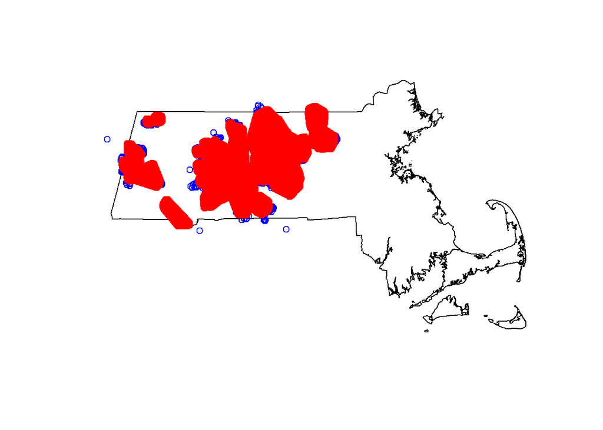

```r
plot(mass_outline$geometry)
plot(shapefile$geometry, add = TRUE, col = "blue")
plot(sf_combined$geometry, add = TRUE, col = "red")
```

**Save All Combined Data**

```r
# Set path to where you would like to save the outputs
setwd(path.save)

# Save Use Points data frame
write.csv(df, file = "Use_Data.csv")

# Save Use Points Shapefile
st_write(shapefile, "Use_Points", driver = "ESRI Shapefile", append=FALSE)
```

```
## Deleting layer `Use_Points' using driver `ESRI Shapefile'
## Writing layer `Use_Points' to data source `Use_Points' using driver `ESRI Shapefile'
## Writing 602056 features with 9 fields and geometry type Point.
```

```r
# Save Available Points Shapefile
st_write(sf_combined, "Available_Points", driver = "ESRI Shapefile", append=FALSE)
```

```
## Deleting layer `Available_Points' using driver `ESRI Shapefile'
## Writing layer `Available_Points' to data source
##   `Available_Points' using driver `ESRI Shapefile'
## Writing 1432150 features with 5 fields and geometry type Point.
```